# TM4SF1 in histological-variant bladder cancer

Design-standardised posteriorHCA baseline (v2.2.1 audit-cleanup)

Author

Affiliation

Chen Zhan

SAiGENCI, The University of Adelaide

Published

18 Aug 2026

Abstract

**Version 2.2.1 (audit-cleanup).** Corrects a join-key bug in the v2.2 tissue × sex plotting audit table that caused duplicate rows. No changes to predictions, plots, candidate status or baseline methodology. The bladder-cancer paper identified TM4SF1 as a candidate antigen in histological-variant (HV) tumours. This report standardises Normal/10x3 posteriorHCA tissue × cell-type baselines using design-based weights and screens them for overlap with the HV tumour-epithelial range. An overlap flag is a reproducible follow-up rule, not evidence of toxicity. Figures follow Nature journal style (axis labels and legends only; canvas ≤ 183 mm wide).

# Question and interpretation boundary

**Report version:** v2.2.1 audit-cleanup (`TM4SF1_toxicity_case_study_v2.2.1_audit_cleanup.qmd`). The frozen v2.2 snapshot is `archive/v2.2_visibility/`; v2.1 is at `archive/v2.1_corrected/`; v2 is at `archive/v2_design_standardised/`; v1 is at `archive/v1_observed_profile/`; the original `TM4SF1_toxicity_case_study.qmd` is unchanged.

The report asks which standardised Normal-labelled, 10x Genomics 3 posteriorHCA tissue × cell-type baselines overlap the HV tumour-epithelial TM4SF1 range after the study counts are aligned to each cell-type model’s own offset-zero TMMwsp reference.

An overlap flag is not evidence of toxicity. It is a prioritisation rule for protein localisation, antigen-density, accessibility and functional-killing experiments. Paired/adjacent normal bladder samples are retained as calibration samples and are never called fully healthy tissue. Three have at least 20 epithelial cells (UC04, VAR07 and VAR10), but only VAR07 has a counterpart in the retained tumour cohort, so this is not a matched-pair analysis.

# Analysis map

The biological unit is the patient throughout. Cell-level source data are used only to reproduce the paper figure; cohort inference uses patient-level summed raw counts.

1. Re-read the authors’ released Figure 5 source tables and confirm the TM4SF1 differential-expression rank.
2. Display both the released per-cell contrast and the reconstructed patient-level raw-count contrast.
3. Align the study pseudobulks to each posteriorHCA model’s own offset-zero TMMwsp reference.
4. Estimate patient-cohort latent `log(mu)` with the SAVI study’s negative-binomial/Bayesian-bootstrap method.
5. Predict posteriorHCA `log(mu)` on a biologically admissible Normal/10x3 covariate grid and marginalise with design-based weights (not atlas donor/profile frequencies).
6. Define a model-specific HV tumour-expression anchor and identify supported tissue × cell-type baselines whose posterior overlaps it.

**Colour / mark grammar.**

[output not shown]

**Panel export sizes (mm, width × height).**

| Tier | Size | Used for |
| --- | --- | --- |
| Small (`sm`) | 85 × 80 | Volcano, violin |
| Medium (`md`) | 90 × 75 | Patient CPM, population bars/boxes |
| Large (`lg`) | 120 × 95 | Faceted tissue / sex forest panels |
| Heatmap | 120 × 85 | Tissue × age / ethnicity tiles |
| Full canvas | 183 × 95 | Cohort contrast forest only |

Figure panels follow Nature journal style: axis labels and legends only (no plot titles or subtitles). **183 mm is the maximum patched canvas width**; individual export panels are smaller so they can be assembled with `patchwork`. Only designated full-width plots use the full 183 mm. Captions carry the title.

# Setup

```r
suppressPackageStartupMessages({
  library(SingleCellExperiment)
  library(SummarizedExperiment)
  library(S4Vectors)
  library(DelayedArray)
  library(HDF5Array)
  library(brms)
  library(edgeR)
  library(posterior)
  library(targets)
  library(readxl)
  library(readr)
  library(dplyr)
  library(tidyr)
  library(purrr)
  library(stringr)
  library(tibble)
  library(ggplot2)
  library(scales)
  library(knitr)
  library(RColorBrewer)
  library(digest)
})

options(stringsAsFactors = FALSE, scipen = 6, bitmapType = "cairo")
set.seed(params$seed)

font_cache <- file.path(tempdir(), "tm4sf1-font-cache")
dir.create(font_cache, recursive = TRUE, showWarnings = FALSE)
Sys.setenv(XDG_CACHE_HOME = font_cache)

# Nature double-column canvas cap and patchwork panel sizes (mm).
mm_to_in <- function(mm) mm / 25.4
fig_canvas_mm <- params$fig_width_mm
panel_mm <- list(
  sm = c(w = params$panel_sm_mm, h = 80),
  md = c(w = params$panel_md_mm, h = 75),
  lg = c(w = params$panel_lg_mm, h = 95),
  heatmap = c(w = params$panel_lg_mm, h = 85),
  full = c(w = fig_canvas_mm, h = 95)
)

first_existing <- function(paths, type = c("file", "dir")) {
  type <- match.arg(type)
  paths <- unique(paths[!is.na(paths) & nzchar(paths)])
  hit <- if (type == "file") paths[file.exists(paths)] else paths[dir.exists(paths)]
  if (!length(hit)) {
    return(NULL)
  }
  hit[[1]]
}

hpc_aliases <- function(path) {
  unique(c(
    path,
    sub("^/hpcfs/", "/scratchdata1/", path),
    sub("^/scratchdata1/", "/hpcfs/", path)
  ))
}

locate_case_dir <- function(path) {
  candidates <- unique(c(path, getwd(), file.path(getwd(), "dev", "TM4SF1_bladder")))
  hit <- candidates[file.exists(file.path(
    candidates, "data", "processed", "pseudobulk_tumour_epithelial_counts.rds"
  ))]
  normalizePath(hit[[1]], mustWork = TRUE)
}

locate_model_root <- function(path) {
  hit <- first_existing(hpc_aliases(path), type = "dir")
  normalizePath(hit, mustWork = TRUE)
}

locate_pseudobulk_h5ad <- function(path, current_path = NA_character_) {
  candidates <- unique(c(
    hpc_aliases(path),
    hpc_aliases(current_path),
    "/home/a1237163/lab/Mangiola_ImmuneAtlas/zenodo/pseudobulk_se.h5ad",
    "/hpcfs/groups/phoenix-hpc-mangiola_laboratory/Mangiola_ImmuneAtlas/zenodo/pseudobulk_se.h5ad",
    "/scratchdata1/groups/phoenix-hpc-mangiola_laboratory/Mangiola_ImmuneAtlas/zenodo/pseudobulk_se.h5ad"
  ))
  hit <- first_existing(candidates, type = "file")
  if (is.null(hit)) {
    stop("Could not find the posteriorHCA pseudobulk H5AD.")
  }
  # Prefer a readable /hpcfs or home copy over a /scratchdata1 realpath.
  ordered <- unique(c(
    candidates[file.exists(candidates) & !startsWith(candidates, "/scratchdata1/")],
    hit
  ))
  ordered[[1]]
}

hdf5_seed_path <- function(x) {
  if (isS4(x) && methods::.hasSlot(x, "filepath")) {
    return(as.character(x@filepath)[[1]])
  }
  if (isS4(x) && methods::.hasSlot(x, "seed")) {
    return(hdf5_seed_path(x@seed))
  }
  NA_character_
}

relocate_hdf5_seed <- function(x, new_path) {
  if (isS4(x) && methods::.hasSlot(x, "filepath")) {
    x@filepath <- new_path
    return(x)
  }
  if (isS4(x) && methods::.hasSlot(x, "seed")) {
    x@seed <- relocate_hdf5_seed(x@seed, new_path)
  }
  x
}

relocate_se_hdf5 <- function(se, new_path) {
  se@assays@data@listData <- lapply(
    se@assays@data@listData,
    relocate_hdf5_seed,
    new_path = new_path
  )
  se
}

case_dir <- locate_case_dir(params$case_dir)
model_root <- locate_model_root(params$model_root)
results_dir <- file.path(case_dir, "results", "tm4sf1_toxicity_report_v2.2.1_audit_cleanup")
cache_dir <- file.path(results_dir, "cache")
v1_results_dir <- file.path(case_dir, params$v1_results_dir)
v2_results_dir <- file.path(case_dir, params$v2_results_dir)
figure_dir <- file.path("results", "tm4sf1_toxicity_report_v2.2.1_audit_cleanup", "figures")
dir.create(cache_dir, recursive = TRUE, showWarnings = FALSE)
dir.create(figure_dir, recursive = TRUE, showWarnings = FALSE)

knitr::opts_chunk$set(fig.path = paste0(figure_dir, "/"))

analysis_version <- "tm4sf1-logmu-v9-design-standardised-v2.2.1-2026-08-18"
tm4_id <- params$gene_ensembl
tm4_symbol <- params$gene_symbol

fingerprint_files <- c(
  file.path(case_dir, "data", "processed", "pseudobulk_tumour_epithelial_counts.rds"),
  file.path(case_dir, "data", "processed", "pseudobulk_paired_normal_epithelial_counts.rds"),
  file.path(case_dir, "data", "raw", "paper", "41467_2025_59888_MOESM4_ESM.xlsx"),
  file.path(model_root, "_PAK2_TM4SF1_modelled_cell_types.csv"),
  file.path(model_root, paste0("V1_", params$model_cell_types), "_targets", "meta", "meta")
)
input_fingerprint <- digest::digest(
  setNames(
    vapply(
      fingerprint_files, digest::digest, character(1),
      algo = "sha256", file = TRUE, serialize = FALSE
    ),
    fingerprint_files
  ),
  algo = "sha256"
)
analysis_id <- paste(
  analysis_version,
  paste0("gene=", tm4_id),
  paste0("models=", paste(params$model_cell_types, collapse = ",")),
  paste0("n_boot=", params$n_boot),
  paste0("threshold_q=", params$threshold_quantile),
  paste0("alert_p=", params$alert_probability),
  paste0("min_donors=", params$min_donor_keys),
  paste0("seed=", params$seed),
  paste0("inputs=", input_fingerprint),
  sep = "|"
)

# Okabe–Ito / Nature-safe colours.
col_hv <- "#D55E00"
col_uc <- "#0072B2"
col_normal <- "#009E73"
col_candidate <- "#D55E00"
col_other <- "#8C8C8C"
col_dark <- "#3F3F3F"
colmap_histology <- c(HV = col_hv, UC = col_uc)
colmap_compartment <- c(
  tumour = col_hv,
  "paired/adjacent normal" = col_normal
)
colmap_cell <- c(epithelial = col_hv, endothelial = col_uc)
colmap_sex <- setNames(brewer.pal(3, "PRGn")[c(1, 3)], c("female", "male"))

theme_multipanel <-
  theme_bw() +
  theme(
    panel.border = element_blank(),
    axis.line = element_line(linewidth = 0.1),
    panel.grid.major = element_blank(),
    panel.grid.minor = element_blank(),
    legend.position = "bottom",
    strip.background = element_blank(),
    axis.title.y = element_text(margin = margin(0, 0, 0, 0), size = 7),
    axis.title.x = element_text(margin = margin(0, 0, 0, 0), size = 7),
    panel.spacing.x = unit(0.1, "lines"),
    axis.text.x = element_text(size = 6),
    axis.text.y = element_text(size = 6),
    strip.text.x = element_text(size = 7),
    strip.text.y = element_text(size = 7),
    legend.key.size = unit(4, "mm"),
    legend.title = element_text(size = 7),
    legend.text = element_text(size = 6),
    strip.clip = "off",
    plot.title = element_blank(),
    plot.subtitle = element_blank(),
    plot.tag = element_text(size = 8, face = "bold"),
    axis.line.x = element_line(linewidth = 0.2),
    axis.line.y = element_line(linewidth = 0.2),
    axis.ticks.x = element_line(linewidth = 0.2),
    axis.ticks.y = element_line(linewidth = 0.2),
    plot.margin = margin(2, 4, 2, 2)
  )

# Drop the leading zero on decimal tick labels (0.1 -> .1).
label_drop_leading_zero <- function(accuracy = NULL, ...) {
  function(x) {
    s <- number(x, accuracy = accuracy, big.mark = "", trim = TRUE, ...)
    s[!is.na(x) & x == 0] <- "0"
    sub("^(-?)0\\.", "\\1.", s)
  }
}

options(
  ggplot2.continuous.y = function() {
    scale_y_continuous(labels = label_drop_leading_zero())
  }
)

save_figure <- function(plot, filename, width_mm, height_mm) {
  stopifnot(width_mm <= fig_canvas_mm)
  stem <- tools::file_path_sans_ext(filename)
  pdf_path <- file.path(figure_dir, paste0(stem, ".pdf"))
  png_path <- file.path(figure_dir, paste0(stem, ".png"))
  pdf_device <- if (isTRUE(capabilities("cairo"))) cairo_pdf else "pdf"
  ggsave(
    pdf_path, plot,
    width = width_mm, height = height_mm, units = "mm",
    dpi = 600, device = pdf_device
  )
  ggsave(
    png_path, plot,
    width = width_mm, height = height_mm, units = "mm",
    dpi = 600
  )
  invisible(plot)
}
```

# 1. Reproduce the paper’s TM4SF1 highlight

```r
paper_workbook <- file.path(
  case_dir, "data", "raw", "paper", "41467_2025_59888_MOESM4_ESM.xlsx"
)

paper_de <- read_excel(paper_workbook, sheet = "Figure5A") |>
  filter(cluster == "Variant") |>
  mutate(
    gene = as.character(gene),
    hv_enriched = avg_log2FC > 0,
    hv_rank = rank(
      if_else(hv_enriched, p_val, NA_real_),
      ties.method = "min",
      na.last = "keep"
    ),
    minus_log10_fdr = -log10(pmax(p_val_adj, .Machine$double.xmin)),
    is_tm4sf1 = gene == tm4_symbol
  )

tm4_paper_de <- paper_de |>
  filter(is_tm4sf1) |>
  transmute(
    source = "paper Figure5A",
    gene,
    avg_log2FC,
    pct_HV = pct.1,
    pct_UC = pct.2,
    p_value = p_val,
    adjusted_p_value = p_val_adj,
    HV_enriched_rank = as.integer(hv_rank)
  )

replication_de <- read_tsv(
  file.path(case_dir, "results", "replication_audit", "TM4SF1_original_DE_result.tsv"),
  show_col_types = FALSE
) |>
  transmute(
    analysis,
    n_HV_patients,
    n_UC_patients,
    cells_per_patient = n_cells_per_patient,
    avg_log2FC,
    p_value = p_val,
    adjusted_p_value = coalesce(FDR_BH, p_val_adj),
    HV_enriched_rank = HV_enriched_rank_by_p
  )

write_tsv(replication_de, file.path(results_dir, "TM4SF1_paper_DE_replication.tsv"))
```

The released table places TM4SF1 at rank 1 among HV-enriched genes: log2 fold change 2.36, detection 37.6% in HV versus 2.9% in pure UC, and adjusted (p = 4.45e-40). The closest public-DGE reconstruction also ranks TM4SF1 first, but it contains 9 HV and only 2 UC patients at the paper’s 150-cell minimum because the deposited UC01 matrix does not contain the published UC01 barcodes.

```r
replication_de |>
  mutate(
    avg_log2FC = round(avg_log2FC, 2),
    p_value = format(p_value, scientific = TRUE, digits = 3),
    adjusted_p_value = format(adjusted_p_value, scientific = TRUE, digits = 3)
  ) |>
  kable(
    caption = "TM4SF1 in the released paper result and public-DGE sensitivity analyses."
  )
```

TM4SF1 in the released paper result and public-DGE sensitivity analyses.

| analysis | n_HV_patients | n_UC_patients | cells_per_patient | avg_log2FC | p_value | adjusted_p_value | HV_enriched_rank |
| --- | --- | --- | --- | --- | --- | --- | --- |
| paper_released_source_DE_9HV_3UC_150_cells_per_patient_unknown_seed | 9 | 3 | 150 | 2.36 | 1.68e-44 | 4.45e-40 | 1 |
| closest_public_DGE_9HV_2UC_150_cells_per_patient_seed293189 | 9 | 2 | 150 | 4.30 | 2.06e-29 | 2.38e-26 | 1 |
| secondary_public_DGE_9HV_3UC_90_cells_per_patient_seed293189 | 9 | 3 | 90 | 2.42 | 1.82e-11 | 2.26e-09 | 28 |

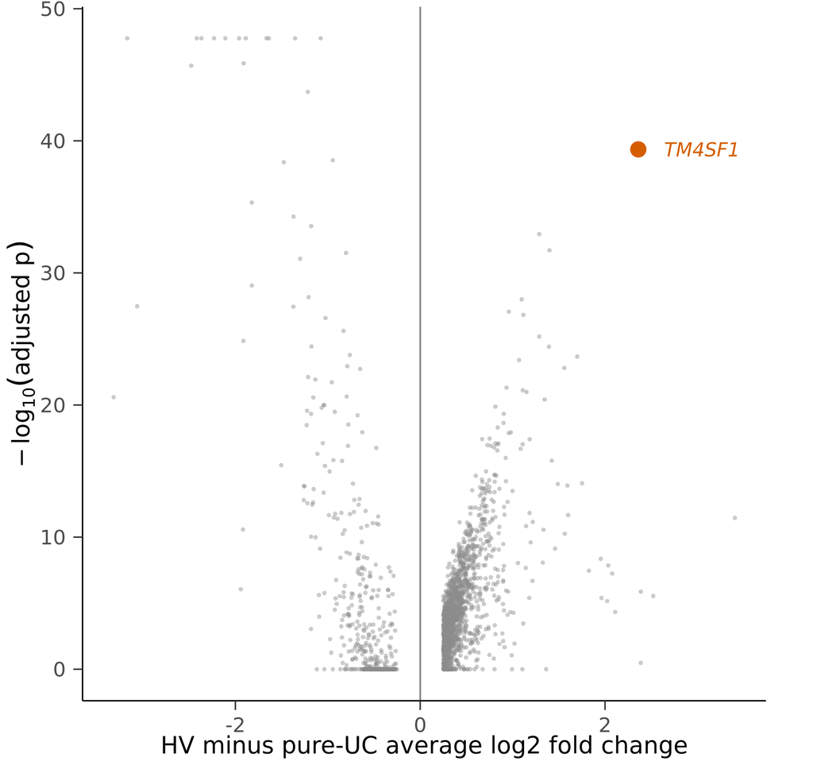

Released Figure 5A differential-expression table. TM4SF1 is highlighted without recomputing the authors’ private object. Extreme −log10 adjusted p values are capped at the 99.5th percentile for display.

```r
volcano_cap <- quantile(paper_de$minus_log10_fdr, 0.995, na.rm = TRUE)
paper_de_display <- paper_de |>
  mutate(plot_y = pmin(minus_log10_fdr, volcano_cap))

paper_de_plot <- ggplot(paper_de_display, aes(avg_log2FC, plot_y)) +
  geom_point(colour = col_other, alpha = 0.45, size = 0.6, stroke = 0) +
  geom_point(
    data = filter(paper_de_display, is_tm4sf1),
    colour = col_hv, size = 1.6
  ) +
  geom_text(
    data = filter(paper_de_display, is_tm4sf1),
    aes(label = gene),
    colour = col_hv, nudge_x = 0.28, hjust = 0,
    size = 2, fontface = "italic"
  ) +
  geom_vline(xintercept = 0, colour = col_other, linewidth = 0.25) +
  coord_cartesian(clip = "off") +
  labs(
    x = "HV minus pure-UC average log2 fold change",
    y = expression(-log[10](adjusted~p))
  ) +
  theme_multipanel +
  theme(plot.margin = margin(2, 14, 2, 2))

save_figure(
  paper_de_plot, "01_paper_Figure5A_TM4SF1_volcano",
  panel_mm$sm["w"], panel_mm$sm["h"]
)
paper_de_plot
```

# 2. Visualise TM4SF1 in the paper cohort

```r
paper_cells <- read_excel(paper_workbook, sheet = "Figure5B") |>
  transmute(
    barcode = as.character(Barcode),
    paper_id = as.character(Name),
    source_expression = as.numeric(TM4SF1),
    histology_group = case_when(
      str_starts(paper_id, "VAR") ~ "HV",
      str_starts(paper_id, "UC") ~ "UC",
      TRUE ~ "other"
    )
  ) |>
  filter(histology_group %in% c("HV", "UC"))

paper_cell_patient <- paper_cells |>
  group_by(paper_id, histology_group) |>
  summarise(
    n_cells = n(),
    mean_source_expression = mean(source_expression),
    median_source_expression = median(source_expression),
    source_nonzero_fraction = mean(source_expression > 1e-8),
    .groups = "drop"
  )

write_tsv(
  paper_cell_patient,
  file.path(results_dir, "TM4SF1_paper_source_patient_summary.tsv")
)
```

The authors released normalized per-cell TM4SF1 values—not raw UMI counts—for 8553 tumour epithelial cells across 9 HV and 3 UC patients. The cell distributions reproduce the figure, but they are descriptive; patients, not cells, are the independent units. Raw DGE counts are used for detection and cohort modelling below.

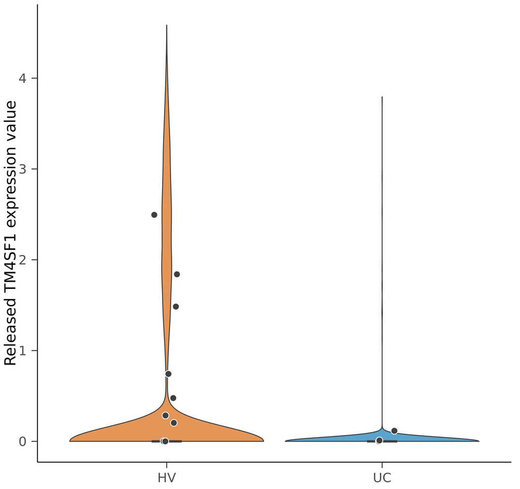

Released Figure 5B TM4SF1 values. The violin is cell-level source data; filled points are patient means.

```r
paper_cell_plot <- ggplot(
  paper_cells,
  aes(histology_group, source_expression, fill = histology_group)
) +
  geom_violin(
    scale = "width", trim = TRUE,
    colour = col_dark, linewidth = 0.2, alpha = 0.65
  ) +
  geom_boxplot(
    width = 0.14, outlier.shape = NA,
    fill = "white", colour = col_dark, linewidth = 0.25
  ) +
  geom_point(
    data = paper_cell_patient,
    inherit.aes = FALSE,
    aes(histology_group, mean_source_expression),
    position = position_jitter(width = 0.06, height = 0),
    shape = 21, fill = col_dark, colour = "white", size = 1.3, stroke = 0.25
  ) +
  scale_fill_manual(values = colmap_histology) +
  labs(x = NULL, y = "Released TM4SF1 expression value") +
  theme_multipanel +
  guides(fill = "none")

save_figure(
  paper_cell_plot, "02_paper_Figure5B_TM4SF1_cells",
  panel_mm$sm["w"], panel_mm$sm["h"]
)
paper_cell_plot
```

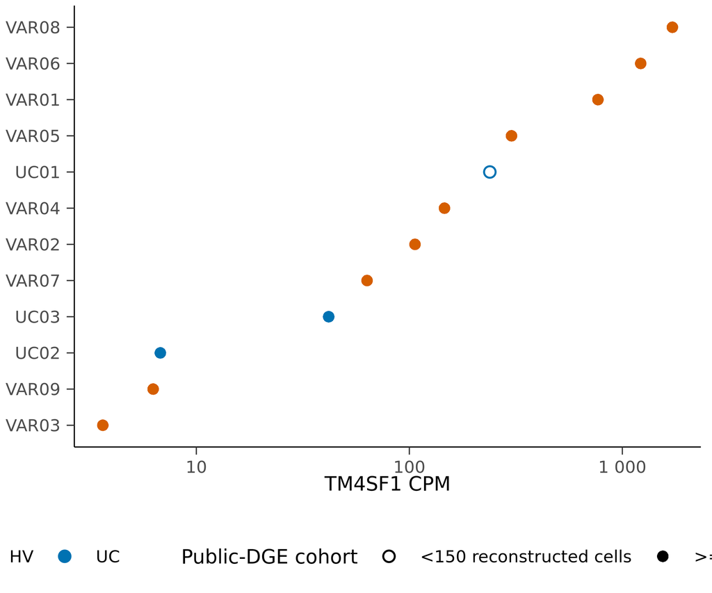

Patient-level raw-count pseudobulk contrast reconstructed from the deposited DGE matrices. UC01 is retained but marked because it has only 90 reconstructed tumour epithelial cells. VAR08 contributes most HV molecules; several HV tumours are low.

```r
tm4_patient <- read_tsv(
  file.path(case_dir, "data", "metadata", "TM4SF1_patient_summary.tsv"),
  show_col_types = FALSE
) |>
  filter(
    sample_type == "tumour",
    broad_cell_type == "epithelial",
    paper_id %in% c(sprintf("VAR%02d", 1:9), sprintf("UC%02d", 1:3))
  ) |>
  mutate(
    cohort_status = if_else(
      reconstructed_n150_threshold_met,
      ">=150 reconstructed cells",
      "<150 reconstructed cells"
    ),
    paper_id = factor(paper_id, levels = paper_id[order(CPM)])
  )

patient_cpm_plot <- ggplot(
  tm4_patient,
  aes(paper_id, CPM, colour = histology_group, shape = cohort_status)
) +
  geom_point(size = 1.6) +
  scale_y_log10(labels = label_number()) +
  scale_colour_manual(values = colmap_histology, name = "Histology") +
  scale_shape_manual(values = c(
    ">=150 reconstructed cells" = 16,
    "<150 reconstructed cells" = 1
  ), name = "Public-DGE cohort") +
  coord_flip() +
  labs(x = NULL, y = "TM4SF1 CPM") +
  theme_multipanel

save_figure(
  patient_cpm_plot, "03_public_DGE_TM4SF1_patient_CPM",
  panel_mm$md["w"], panel_mm$md["h"]
)
patient_cpm_plot
```

## Which broad population carries TM4SF1?

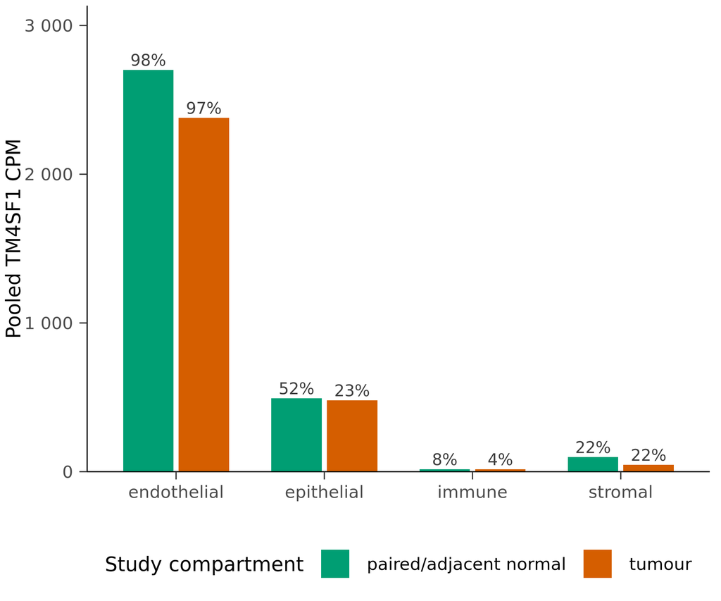

Pooled TM4SF1 abundance and detection across broad reconstructed populations. Labels give the fraction of cells with non-zero counts. Endothelium is a key cell class for off-tumour follow-up.

```r
population_source <- read_tsv(
  file.path(case_dir, "data", "metadata", "TM4SF1_population_source_summary.tsv"),
  show_col_types = FALSE
) |>
  mutate(
    sample_type = recode(
      sample_type,
      paired_normal = "paired/adjacent normal",
      tumour = "tumour"
    )
  )

population_plot <- ggplot(
  population_source,
  aes(broad_cell_type, pooled_CPM, fill = sample_type)
) +
  geom_col(position = position_dodge(width = 0.75), width = 0.68, colour = NA) +
  geom_text(
    aes(label = percent(pooled_detection_rate, accuracy = 1)),
    position = position_dodge(width = 0.75),
    vjust = -0.35, size = 2, colour = col_dark
  ) +
  scale_y_continuous(
    labels = label_number(),
    expand = expansion(mult = c(0, 0.16))
  ) +
  scale_fill_manual(values = colmap_compartment, name = "Study compartment") +
  labs(x = NULL, y = "Pooled TM4SF1 CPM") +
  theme_multipanel

save_figure(
  population_plot, "04_TM4SF1_broad_population_source",
  panel_mm$md["w"], panel_mm$md["h"]
)
population_plot
```

Because pooled CPM is composition-weighted, the same check is shown at patient level:

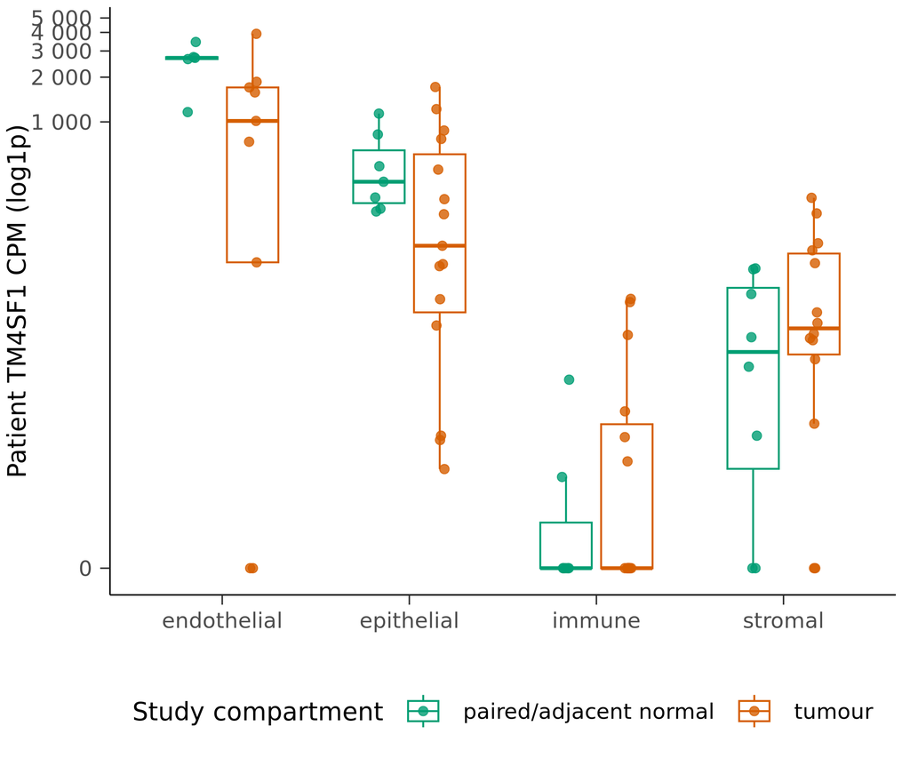

Patient-level TM4SF1 CPM by broad population and study compartment. Points are patient pseudobulks; low-cell profiles remain descriptive.

```r
population_patient <- read_tsv(
  file.path(case_dir, "data", "metadata", "TM4SF1_patient_summary.tsv"),
  show_col_types = FALSE
) |>
  filter(broad_cell_type %in% c("epithelial", "endothelial", "stromal", "immune")) |>
  mutate(
    sample_type = recode(
      sample_type,
      paired_normal = "paired/adjacent normal",
      tumour = "tumour"
    )
  )

population_patient_plot <- ggplot(
  population_patient,
  aes(broad_cell_type, CPM, colour = sample_type)
) +
  geom_boxplot(
    aes(group = interaction(broad_cell_type, sample_type)),
    outlier.shape = NA, width = 0.55, linewidth = 0.25, alpha = 0.15,
    position = position_dodge(width = 0.65)
  ) +
  geom_point(
    position = position_jitterdodge(jitter.width = 0.1, dodge.width = 0.65),
    alpha = 0.8, size = 1.1, stroke = 0.2
  ) +
  scale_y_continuous(trans = transform_log1p(), labels = label_number()) +
  scale_colour_manual(values = colmap_compartment, name = "Study compartment") +
  labs(x = NULL, y = "Patient TM4SF1 CPM (log1p)") +
  theme_multipanel

save_figure(
  population_patient_plot,
  "04b_TM4SF1_broad_population_patient_CPM",
  panel_mm$md["w"], panel_mm$md["h"]
)
population_patient_plot
```

Together, the pooled and patient-level checks motivate the comparator strategy. Epithelium is the closest cell-class-matched comparator for tumour epithelium, while endothelium must be analysed separately because its expression may represent a vascular off-tumour exposure. Pooling these classes would hide the relevant biology.

# 3. Cohort-level `log(mu)` and posteriorHCA baseline

The helper functions below remain in the report. They implement one chain from raw patient counts to model-aligned `log(mu)`.

## Study-side helpers

```r
# Collapse feature rows that share an Ensembl id.
aggregate_ensembl_counts <- function(se) {
  counts <- as.matrix(assay(se, "counts"))
  ensembl <- as.character(rowData(se)$ensembl_id)
  keep <- !is.na(ensembl) & nzchar(ensembl)
  out <- rowsum(counts[keep, , drop = FALSE], ensembl[keep], reorder = FALSE)
  storage.mode(out) <- "numeric"
  out
}

read_study_pseudobulk <- function(case_dir) {
  tumour_se <- readRDS(file.path(
    case_dir, "data", "processed", "pseudobulk_tumour_epithelial_counts.rds"
  ))
  normal_se <- readRDS(file.path(
    case_dir, "data", "processed",
    "pseudobulk_paired_normal_epithelial_counts.rds"
  ))

  tumour_counts <- aggregate_ensembl_counts(tumour_se)
  normal_counts <- aggregate_ensembl_counts(normal_se)

  tumour_meta <- as.data.frame(colData(tumour_se)) |>
    rownames_to_column("source_column") |>
    mutate(
      analysis_group = histology_group,
      study_state = "tumour epithelial",
      include_for_logmu = TRUE
    )
  normal_meta <- as.data.frame(colData(normal_se)) |>
    rownames_to_column("source_column") |>
    mutate(
      analysis_group = "paired_normal",
      study_state = "paired-normal epithelial",
      include_for_logmu = n_cells >= 20
    )

  common <- intersect(rownames(tumour_counts), rownames(normal_counts))
  normal_keep <- normal_meta$include_for_logmu
  counts <- cbind(
    tumour_counts[common, , drop = FALSE],
    normal_counts[common, normal_keep, drop = FALSE]
  )
  meta <- bind_rows(tumour_meta, normal_meta[normal_keep, , drop = FALSE]) |>
    mutate(
      analysis_column = c(
        paste0("tumour__", tumour_meta$patient_id),
        paste0("paired_normal_epithelial__", normal_meta$patient_id[normal_keep])
      ),
      strict_n150 = study_state != "tumour epithelial" |
        reconstructed_n150_threshold_met
    )

  colnames(counts) <- meta$analysis_column
  rownames(meta) <- meta$analysis_column
  list(counts = counts, metadata = meta)
}

# TMM against the model's own offset-zero reference sample.
align_to_hca_reference <- function(study_counts, reference_counts, reference_name) {
  shared <- intersect(rownames(study_counts), names(reference_counts))
  combined <- cbind(
    study_counts[shared, , drop = FALSE],
    setNames(reference_counts[shared], shared)
  )
  colnames(combined)[ncol(combined)] <- reference_name

  norm_factors <- calcNormFactors(
    combined, refColumn = ncol(combined), method = "TMMwsp"
  )
  library_size <- colSums(combined)
  effective_size <- library_size * norm_factors
  multiplier <- effective_size[[reference_name]] / effective_size
  offset <- log(1 / multiplier)

  list(
    counts = combined[, colnames(study_counts), drop = FALSE],
    offset = offset[colnames(study_counts)],
    multiplier = multiplier[colnames(study_counts)],
    shared_features = shared
  )
}

fit_shared_dispersion <- function(counts, metadata, offset, feature_id) {
  design <- model.matrix(~ 0 + factor(metadata$analysis_group))
  dge <- DGEList(counts = counts)
  dge$offset <- matrix(offset, nrow(counts), ncol(counts), byrow = TRUE)

  keep <- filterByExpr(dge, design = design)
  keep[match(feature_id, rownames(dge))] <- TRUE
  dge <- dge[keep, , keep.lib.sizes = FALSE]
  dge <- estimateDisp(dge, design, robust = TRUE)
  invisible(glmQLFit(dge, design, robust = TRUE))

  dispersion <- if (!is.null(dge$trended.dispersion)) {
    dge$trended.dispersion
  } else if (!is.null(dge$tagwise.dispersion)) {
    dge$tagwise.dispersion
  } else {
    rep_len(dge$common.dispersion, nrow(dge))
  }
  names(dispersion) <- rownames(dge)
  unname(dispersion[[feature_id]])
}

draw_dirichlet_weights <- function(n) {
  weights <- rexp(n)
  n * weights / sum(weights)
}

bootstrap_cohort_logmu <- function(counts, offset, dispersion, columns, n_boot, seed) {
  y <- counts[tm4_id, columns, drop = FALSE]
  o <- offset[columns]
  set.seed(seed)
  vapply(seq_len(n_boot), function(i) {
    mglmOneGroup(
      y, offset = o, dispersion = dispersion,
      weights = draw_dirichlet_weights(length(columns))
    )[[1]]
  }, numeric(1))
}

pair_log2_contrast <- function(x, y, n = 2000L, seed = 1L) {
  set.seed(seed)
  delta <- (sample(x, n, replace = TRUE) - sample(y, n, replace = TRUE)) / log(2)
  tibble(
    estimate_log2 = median(delta),
    lower_log2 = quantile(delta, 0.025),
    upper_log2 = quantile(delta, 0.975),
    probability_positive = mean(delta > 0)
  )
}
```

## posteriorHCA helpers (v2.1 corrected admissibility)

```r
read_hca_bundle <- function(cell_type, model_root, feature_id) {
  store <- file.path(model_root, paste0("V1_", cell_type), "_targets")
  registry <- read.csv(
    file.path(model_root, "_PAK2_TM4SF1_modelled_cell_types.csv"),
    check.names = FALSE
  )
  target_name <- registry |>
    filter(
      cell_type == paste0("V1_", .env$cell_type),
      ensembl_id == feature_id,
      isTRUE(in_feature_df) | in_feature_df
    ) |>
    pull(estimates_branch) |>
    unique()

  chunk <- targets::tar_read_raw(target_name[[1]], store = store)
  fit <- chunk$brms_fit[[match(feature_id, chunk$.feature)]]
  pseudobulk <- targets::tar_read_raw("pseudobulk_sample", store = store)

  current_h5ad <- hdf5_seed_path(pseudobulk@assays@data@listData[["counts"]])
  h5ad <- locate_pseudobulk_h5ad(params$pseudobulk_h5ad, current_h5ad)
  pseudobulk <- relocate_se_hdf5(pseudobulk, h5ad)
  sample_meta <- as.data.frame(colData(pseudobulk)) |>
    rownames_to_column("sample_column")
  counts <- assay(pseudobulk, "counts")

  reference_index <- which(sample_meta$offset == 0)
  if (length(reference_index) != 1L) {
    stop(
      "Expected exactly one offset==0 reference sample in ", cell_type,
      "; found ", length(reference_index)
    )
  }
  reference_name <- sample_meta$sample_column[[reference_index]]
  reference_counts <- as.numeric(as.matrix(counts[, reference_index, drop = FALSE]))
  names(reference_counts) <- rownames(pseudobulk)

  profiles <- sample_meta |>
    transmute(
      sample_column,
      dataset_id = as.character(dataset_id),
      donor_id = as.character(donor_id),
      tissue = as.character(tissue),
      tissue_groups = as.character(tissue_groups),
      age_decade = as.character(age_decade),
      sex = as.character(sex),
      ethnicity_groups = as.character(ethnicity_groups),
      disease_group = as.character(disease_groups),
      assay_group = as.character(assay_groups)
    ) |>
    filter(
      disease_group == "Normal",
      assay_group == "10x Genomics 3",
      if_all(
        c(dataset_id, donor_id, tissue_groups, age_decade, sex, ethnicity_groups),
        ~ !is.na(.x) & nzchar(.x)
      )
    ) |>
    mutate(donor_key = paste(dataset_id, donor_id, sep = "___")) |>
    distinct(
      donor_key, tissue_groups, age_decade, sex, ethnicity_groups,
      .keep_all = TRUE
    )

  fit_draws <- posterior::as_draws_array(fit)
  draw_diagnostics <- posterior::summarise_draws(fit_draws)
  nuts <- brms::nuts_params(fit)
  finite_max <- function(x) {
    x <- x[is.finite(x)]
    if (length(x)) max(x) else NA_real_
  }
  finite_min <- function(x) {
    x <- x[is.finite(x)]
    if (length(x)) min(x) else NA_real_
  }

  max_rhat_value <- finite_max(draw_diagnostics$rhat)
  min_ess_bulk_value <- finite_min(draw_diagnostics$ess_bulk)
  min_ess_tail_value <- finite_min(draw_diagnostics$ess_tail)
  divergence_count <- sum(
    nuts$Parameter == "divergent__" & nuts$Value == 1,
    na.rm = TRUE
  )

  diagnostics <- tibble(
    cell_type,
    n_model_rows = nrow(fit$data),
    n_posterior_draws = posterior::ndraws(fit_draws),
    max_rhat = max_rhat_value,
    min_ess_bulk = min_ess_bulk_value,
    min_ess_tail = min_ess_tail_value,
    divergences = divergence_count,
    readiness_policy = "Rhat<=1.01; bulk/tail ESS>=400; zero divergences",
    model_ready = all(is.finite(c(
      max_rhat_value, min_ess_bulk_value, min_ess_tail_value, divergence_count
    ))) &
      max_rhat_value <= 1.01 &
      min_ess_bulk_value >= 400 &
      min_ess_tail_value >= 400 &
      divergence_count == 0
  )

  list(
    fit = fit,
    profiles = profiles,
    reference_counts = reference_counts,
    reference_name = reference_name,
    model_store = store,
    target_name = target_name[[1]],
    diagnostics = diagnostics
  )
}

posterior_hca_logmu <- function(fit, newdata, seed) {
  set.seed(seed)
  brms::posterior_linpred(
    fit,
    newdata = newdata,
    transform = FALSE,
    re_formula = NULL,
    allow_new_levels = TRUE,
    sample_new_levels = "gaussian"
  )
}

## Layer 1 — Biological sex admissibility registry (cell-type independent)

structural_sex_constraints <- c(
  "female reproductive system" = "female",
  "male reproductive system" = "male",
  "prostate" = "male",
  "testis" = "male",
  "ovary" = "female"
)

analysis_sex_restrictions <- c(
  "breast" = "female"
)

excluded_ethnicity_levels <- "Other/Unknown"

biologically_allowed_sexes <- function(tissue) {
  if (tissue %in% names(structural_sex_constraints)) {
    return(structural_sex_constraints[[tissue]])
  }
  c("female", "male")
}

sex_restriction_type <- function(tissue) {
  if (tissue %in% names(structural_sex_constraints)) {
    return("hard structural constraint")
  }
  if (tissue %in% names(analysis_sex_restrictions)) {
    return("analysis restriction (not structural)")
  }
  "both sexes biologically valid"
}

is_sex_restricted <- function(tissue) {
  tissue %in% names(structural_sex_constraints) ||
    tissue %in% names(analysis_sex_restrictions)
}

allowed_sexes_for_tissue <- function(tissue) {
  if (tissue %in% names(structural_sex_constraints)) {
    return(structural_sex_constraints[[tissue]])
  }
  if (tissue %in% names(analysis_sex_restrictions)) {
    return(analysis_sex_restrictions[[tissue]])
  }
  c("female", "male")
}

reports_both_sexes <- function(tissue) {
  length(allowed_sexes_for_tissue(tissue)) >= 2L
}

build_tissue_sex_rules <- function(tissues, profiles) {
  map_dfr(sort(unique(tissues)), function(tissue) {
    bio_allowed <- biologically_allowed_sexes(tissue)
    analysis_allowed <- allowed_sexes_for_tissue(tissue)
    atlas_observed <- sort(unique(
      profiles$sex[profiles$tissue_groups == tissue]
    ))
    tibble(
      tissue_groups = tissue,
      biologically_allowed_sex = paste(bio_allowed, collapse = ", "),
      analysis_allowed_sex = paste(analysis_allowed, collapse = ", "),
      atlas_observed_sex = paste(atlas_observed, collapse = ", "),
      n_biologically_allowed = length(bio_allowed),
      n_analysis_allowed = length(analysis_allowed),
      reports_tissue_sex = reports_both_sexes(tissue),
      restriction_type = sex_restriction_type(tissue),
      has_unobserved_target_sex = !all(analysis_allowed %in% atlas_observed)
    )
  })
}
```

```r
## Layer 2 — Target grid and prediction

build_target_grid <- function(profiles, min_donors) {
  tissues <- sort(unique(profiles$tissue_groups))
  age_levels <- sort(unique(profiles$age_decade))
  eth_levels <- sort(unique(profiles$ethnicity_groups))
  eth_levels <- setdiff(eth_levels, excluded_ethnicity_levels)

  observed_support <- profiles |>
    group_by(tissue_groups, sex, age_decade, ethnicity_groups) |>
    summarise(
      n_donor_keys = n_distinct(donor_key),
      n_profile_rows = n(),
      .groups = "drop"
    )

  target_grid <- map_dfr(tissues, function(tissue) {
    target_sexes <- allowed_sexes_for_tissue(tissue)
    tidyr::crossing(
      tissue_groups = tissue,
      sex = target_sexes,
      age_decade = age_levels,
      ethnicity_groups = eth_levels
    )
  }) |>
    left_join(observed_support, by = c(
      "tissue_groups", "sex", "age_decade", "ethnicity_groups"
    )) |>
    mutate(
      n_donor_keys = coalesce(n_donor_keys, 0L),
      n_profile_rows = coalesce(n_profile_rows, 0L),
      direct_empirical_support = n_donor_keys > 0L,
      requires_extrapolation = !direct_empirical_support,
      restriction_type = vapply(
        tissue_groups, sex_restriction_type, character(1)
      )
    )
  target_grid
}

design_cells_to_newdata <- function(cells) {
  cells |>
    transmute(
      counts = 1,
      age_decade,
      sex,
      disease_groups_altered = "Normal",
      ethnicity_groups,
      assay_groups_altered = "10x Genomics 3",
      dataset_id_altered = "__TM4SF1_new_study__",
      tissue_groups,
      offset = 0
    )
}

## Nested equal-weight marginalisation

nested_marginal_draws <- function(logmu, cells) {
  if (!nrow(cells)) {
    return(numeric())
  }
  sex_levels <- sort(unique(cells$sex))
  sex_draws <- map(sex_levels, function(sex_level) {
    sex_cells <- dplyr::filter(cells, sex == sex_level)
    age_levels <- sort(unique(sex_cells$age_decade))
    age_draws <- map(age_levels, function(age_level) {
      age_cells <- dplyr::filter(sex_cells, age_decade == age_level)
      eth_levels <- sort(unique(age_cells$ethnicity_groups))
      eth_draws <- map(eth_levels, function(eth_level) {
        idx <- age_cells$row_idx[age_cells$ethnicity_groups == eth_level]
        if (length(idx) == 1L) logmu[, idx] else rowMeans(logmu[, idx, drop = FALSE])
      })
      Reduce(`+`, eth_draws) / length(eth_draws)
    })
    Reduce(`+`, age_draws) / length(age_draws)
  })
  Reduce(`+`, sex_draws) / length(sex_draws)
}

tissue_baseline_draw <- function(logmu, cells, tissue) {
  sub <- dplyr::filter(cells, tissue_groups == tissue)
  if (!nrow(sub)) return(numeric())
  nested_marginal_draws(logmu, sub)
}

compute_marginalisation_weights <- function(cells, tissue = NULL) {
  sub <- if (is.null(tissue)) cells else dplyr::filter(cells, tissue_groups == tissue)
  if (!nrow(sub)) return(tibble())

  sex_levels <- sort(unique(sub$sex))
  n_sex <- length(sex_levels)
  map_dfr(sex_levels, function(sx) {
    sex_cells <- dplyr::filter(sub, sex == sx)
    age_levels <- sort(unique(sex_cells$age_decade))
    n_age <- length(age_levels)
    map_dfr(age_levels, function(ag) {
      age_cells <- dplyr::filter(sex_cells, age_decade == ag)
      eth_levels <- sort(unique(age_cells$ethnicity_groups))
      n_eth <- length(eth_levels)
      map_dfr(eth_levels, function(et) {
        cell <- dplyr::filter(age_cells, ethnicity_groups == et)
        tibble(
          tissue_groups = cell$tissue_groups[[1]],
          sex = sx, age_decade = ag, ethnicity_groups = et,
          n_donor_keys = cell$n_donor_keys[[1]],
          direct_empirical_support = cell$direct_empirical_support[[1]],
          requires_extrapolation = cell$requires_extrapolation[[1]],
          marginal_weight = 1 / (n_sex * n_age * n_eth),
          weight_rule = paste0(
            "equal sex (1/", n_sex, ") × equal age (1/", n_age,
            ") × equal ethnicity (1/", n_eth, ")"
          )
        )
      })
    })
  })
}

## Layer 3 — Support diagnostics

compute_support_diagnostics <- function(weights_df, k = 3L) {
  if (!nrow(weights_df)) {
    return(tibble(
      n_target_cells = 0L, n_observed_cells = 0L, n_extrapolated_cells = 0L,
      total_unique_donors = 0L,
      C_obs = 0, C_k = 0, extrapolation_weight = 0
    ))
  }
  tibble(
    n_target_cells = nrow(weights_df),
    n_observed_cells = sum(weights_df$direct_empirical_support),
    n_extrapolated_cells = sum(weights_df$requires_extrapolation),
    total_unique_donors = sum(weights_df$n_donor_keys),
    C_obs = sum(weights_df$marginal_weight[weights_df$direct_empirical_support]),
    C_k = sum(weights_df$marginal_weight[weights_df$n_donor_keys >= k]),
    extrapolation_weight = sum(
      weights_df$marginal_weight[weights_df$requires_extrapolation]
    )
  )
}

## Summarise a design-based group

summarise_design_draw <- function(
    logmu, hv_draws, threshold, seed,
    dimension, cells, fix_cols, min_donors, profiles, k
) {
  if (length(fix_cols)) {
    key <- cells |>
      mutate(across(all_of(fix_cols), as.character)) |>
      group_by(across(all_of(fix_cols))) |>
      group_split()
  } else {
    key <- list(cells)
  }

  map2_dfr(key, seq_along(key), function(group_cells, group_number) {
    if (identical(dimension, "comprehensive")) {
      tissues <- sort(unique(group_cells$tissue_groups))
      tissue_draws_list <- map(tissues, ~ tissue_baseline_draw(logmu, group_cells, .x))
      tissue_draws_list <- tissue_draws_list[lengths(tissue_draws_list) > 0L]
      if (!length(tissue_draws_list)) return(tibble())
      hca_draws <- Reduce(`+`, tissue_draws_list) / length(tissue_draws_list)
    } else {
      hca_draws <- nested_marginal_draws(logmu, group_cells)
      if (!length(hca_draws)) return(tibble())
    }

    pick <- function(name) {
      if (name %in% fix_cols) as.character(group_cells[[name]][[1]]) else NA_character_
    }

    wts <- compute_marginalisation_weights(group_cells)
    support <- compute_support_diagnostics(wts, k = k)
```

```r
    n_donor_keys <- profiles |>
      semi_join(
        group_cells |> filter(direct_empirical_support),
        by = c("tissue_groups", "sex", "age_decade", "ethnicity_groups")
      ) |>
      pull(donor_key) |>
      n_distinct()

    paired <- pair_log2_contrast(
      hca_draws, hv_draws,
      n = max(length(hv_draws), length(hca_draws)),
      seed = seed + group_number
    )

    tibble(
      dimension,
      tissue_groups = pick("tissue_groups"),
      sex = pick("sex"),
      age_decade = pick("age_decade"),
      ethnicity_groups = pick("ethnicity_groups"),
      n_target_cells = support$n_target_cells,
      n_observed_cells = support$n_observed_cells,
      n_extrapolated_cells = support$n_extrapolated_cells,
      n_unique_donor_keys = n_donor_keys,
      C_obs = support$C_obs,
      C_k = support$C_k,
      extrapolation_weight = support$extrapolation_weight,
      median_log_mu = median(hca_draws),
      lower_log_mu = quantile(hca_draws, 0.025),
      upper_log_mu = quantile(hca_draws, 0.975),
      threshold_log_mu = threshold,
      probability_above_threshold = mean(hca_draws >= threshold),
      probability_hca_ge_random_hv = mean(ecdf(hv_draws)(hca_draws)),
      estimate_log2_vs_hv = paired$estimate_log2,
      lower_log2_vs_hv = paired$lower_log2,
      upper_log2_vs_hv = paired$upper_log2,
      supported = dimension == "comprehensive" | n_donor_keys >= min_donors
    )
  })
}

summarise_design_groups <- function(
    logmu, cells, profiles, dimension, fix_cols, hv_draws,
    threshold, min_donors, seed, k
) {
  if (identical(dimension, "tissue_sex")) {
    both_sex <- unique(cells$tissue_groups[
      vapply(cells$tissue_groups, reports_both_sexes, logical(1))
    ])
    cells <- dplyr::filter(cells, tissue_groups %in% both_sex)
  }
  summarise_design_draw(
    logmu, hv_draws, threshold, seed,
    dimension, cells, fix_cols, min_donors, profiles, k
  )
}

compute_tissue_rule_sensitivity <- function(
    logmu, cells, profiles, hv_draws, cell_type,
    threshold_quantiles = c(0.01, 0.05, 0.10),
    minimum_donor_keys = c(5L, 10L, 20L),
    alert_probabilities = c(0.50, 0.80, 0.95)
) {
  tissues <- sort(unique(cells$tissue_groups))
  tissue_draws <- setNames(
    map(tissues, ~ tissue_baseline_draw(logmu, cells, .x)),
    tissues
  )
  tissue_support <- map_int(tissues, function(tissue) {
    profiles |>
      semi_join(
        dplyr::filter(cells, tissue_groups == tissue, direct_empirical_support),
        by = c("tissue_groups", "sex", "age_decade", "ethnicity_groups")
      ) |>
      pull(donor_key) |>
      n_distinct()
  })

  crossing(
    threshold_quantile = threshold_quantiles,
    minimum_donor_keys = minimum_donor_keys,
    alert_probability_cutoff = alert_probabilities
  ) |>
    pmap_dfr(function(
        threshold_quantile, minimum_donor_keys, alert_probability_cutoff
    ) {
      threshold <- unname(quantile(hv_draws, threshold_quantile))
      exceedance <- map_dbl(tissue_draws, ~ mean(.x >= threshold))
      tibble(
        cell_type,
        threshold_quantile,
        threshold_log_mu = threshold,
        minimum_donor_keys,
        alert_probability_cutoff,
        supported_tissues = sum(tissue_support >= minimum_donor_keys),
        prototype_tissue_candidates = sum(
          tissue_support >= minimum_donor_keys &
            exceedance >= alert_probability_cutoff
        )
      )
    })
}
```

## One cell-type model

```r
run_one_cell_type <- function(cell_type, study, params, model_root) {
  bundle <- read_hca_bundle(cell_type, model_root, tm4_id)
  aligned <- align_to_hca_reference(
    study$counts, bundle$reference_counts, bundle$reference_name
  )
  dispersion <- fit_shared_dispersion(
    aligned$counts, study$metadata, aligned$offset, tm4_id
  )

  groups <- list(
    "HV tumour epithelial" = which(
      study$metadata$study_state == "tumour epithelial" &
        study$metadata$histology_group == "HV"
    ),
    "UC tumour epithelial (3 published IDs)" = which(
      study$metadata$study_state == "tumour epithelial" &
        study$metadata$histology_group == "UC"
    ),
    "UC tumour epithelial (2 public-DGE >=150)" = which(
      study$metadata$study_state == "tumour epithelial" &
        study$metadata$histology_group == "UC" &
        study$metadata$strict_n150
    ),
    "paired-normal epithelial (>=20 cells)" = which(
      study$metadata$study_state == "paired-normal epithelial"
    )
  )

  study_draws <- imap_dfr(groups, function(index, group_name) {
    draws <- bootstrap_cohort_logmu(
      aligned$counts,
      aligned$offset,
      dispersion,
      colnames(aligned$counts)[index],
      params$n_boot,
      params$seed + which(names(groups) == group_name)
    )
    tibble(
      cell_type, group = group_name,
      draw = seq_along(draws), log_mu = draws,
      n_patients = length(index)
    )
  })

  hv_draws <- study_draws |>
    filter(group == "HV tumour epithelial") |>
    pull(log_mu)
  threshold <- unname(quantile(hv_draws, params$threshold_quantile))

  target_grid <- build_target_grid(bundle$profiles, params$min_donor_keys)
  tissue_sex_rules <- build_tissue_sex_rules(
    unique(bundle$profiles$tissue_groups), bundle$profiles
  )
  prediction_newdata <- design_cells_to_newdata(target_grid)

  hca_logmu <- posterior_hca_logmu(
    bundle$fit, prediction_newdata,
    seed = params$seed + match(cell_type, params$model_cell_types) * 100L
  )
  cells <- target_grid |>
    mutate(row_idx = row_number())

  k <- params$well_supported_k

  group_specs <- list(
    comprehensive = list(vars = character(), seed = params$seed + 1000L),
    tissue = list(vars = "tissue_groups", seed = params$seed + 2000L),
    tissue_sex = list(vars = c("tissue_groups", "sex"), seed = params$seed + 3000L),
    tissue_age = list(
      vars = c("tissue_groups", "age_decade"), seed = params$seed + 4000L
    ),
    tissue_ethnicity = list(
      vars = c("tissue_groups", "ethnicity_groups"), seed = params$seed + 5000L
    )
  )

  profile_summary <- imap_dfr(group_specs, function(spec, dimension) {
    summarise_design_groups(
      hca_logmu, cells, bundle$profiles, dimension, spec$vars, hv_draws,
      threshold, params$min_donor_keys, spec$seed, k
    )
  }) |>
    mutate(
      cell_type = cell_type,
      baseline_method = params$baseline_method,
      model_ready = bundle$diagnostics$model_ready[[1]],
      interpretable_for_demographic_alert = !(
        dimension == "tissue_ethnicity" & ethnicity_groups == "Other/Unknown"
      ),
      prototype_overlap_candidate = supported &
        interpretable_for_demographic_alert &
        probability_above_threshold >= params$alert_probability,
      expression_overlap_alert = prototype_overlap_candidate & model_ready,
      .before = 1
    )

  marginalisation_weights <- map_dfr(
    sort(unique(cells$tissue_groups)),
    ~ compute_marginalisation_weights(cells, .x) |> mutate(cell_type = cell_type)
  )

  level_audit <- target_grid |>
    mutate(cell_type = cell_type) |>
    select(
      cell_type, tissue_groups, sex, age_decade, ethnicity_groups,
      n_donor_keys, direct_empirical_support, requires_extrapolation,
      restriction_type
    )

  hca_comprehensive <- {
    tissues <- sort(unique(cells$tissue_groups))
    tissue_draws_list <- map(tissues, ~ tissue_baseline_draw(hca_logmu, cells, .x))
    tissue_draws_list <- tissue_draws_list[lengths(tissue_draws_list) > 0L]
    if (length(tissue_draws_list)) {
      Reduce(`+`, tissue_draws_list) / length(tissue_draws_list)
    } else {
      numeric()
    }
  }

  hca_renal <- tissue_baseline_draw(hca_logmu, cells, "renal system")

  rule_sensitivity <- compute_tissue_rule_sensitivity(
    hca_logmu, cells, bundle$profiles, hv_draws, cell_type
  ) |>
    mutate(
      model_ready = bundle$diagnostics$model_ready[[1]],
      analysis_id = analysis_id,
      .after = cell_type
    )

  contrast_draws <- study_draws
  if (cell_type != "epithelial") {
    contrast_draws <- filter(
      contrast_draws, group != "paired-normal epithelial (>=20 cells)"
    )
  }

  cohort_contrasts <- contrast_draws |>
    group_split(group) |>
    map_dfr(function(group_data) {
      comparison_draws <- hca_comprehensive
      comparator <- paste0(
        "posteriorHCA Normal/10x3-supported comprehensive ", cell_type
      )
      if (
        cell_type == "epithelial" &&
          unique(group_data$group) == "paired-normal epithelial (>=20 cells)" &&
          length(hca_renal)
      ) {
        comparison_draws <- hca_renal
        comparator <- paste(
          "posteriorHCA Normal/10x3-supported renal-system",
          "epithelial proxy"
        )
      }
      pair_log2_contrast(
        group_data$log_mu, comparison_draws,
        n = params$n_boot,
        seed = params$seed + 6000L + match(unique(group_data$group), names(groups))
      ) |>
        mutate(
          cell_type,
          study_group = unique(group_data$group),
          comparator,
          n_study_patients = unique(group_data$n_patients),
          .before = 1
        )
    })

  threshold_registry <- tibble(
    gene_symbol = tm4_symbol,
    ensembl_id = tm4_id,
    cell_type_model = cell_type,
    model_store = bundle$model_store,
    model_target = bundle$target_name,
    normalization_reference = bundle$reference_name,
    normalization_method = "TMMwsp; reference-anchored offset=log(1/multiplier)",
    study_biological_unit = "patient",
    tumour_expression_anchor = "9-patient HV tumour epithelial cohort location",
    threshold_quantile = params$threshold_quantile,
    threshold_log_mu = threshold,
    n_patient_bootstrap_draws = params$n_boot,
    random_seed = params$seed,
    alert_probability_cutoff = params$alert_probability,
    minimum_donor_keys = params$min_donor_keys,
    model_ready = bundle$diagnostics$model_ready[[1]],
    diagnostic_gate = bundle$diagnostics$readiness_policy[[1]],
    input_and_model_fingerprint = input_fingerprint,
    shared_feature_count = length(aligned$shared_features),
    shared_feature_sha256 = digest::digest(sort(aligned$shared_features), algo = "sha256"),
    profile_weighting = paste(
      "design-based nested equal weights over biologically admissible",
      "sex × age × ethnicity cells; equal tissue weighting for comprehensive"
    ),
    prediction_policy = paste(
      "Normal; 10x Genomics 3; offset=0; biologically admissible covariate grid;",
      "unseen dataset random effect"
    ),
    analysis_version,
    analysis_id
  )

  list(
    analysis_version = analysis_version,
    analysis_id = analysis_id,
    cell_type = cell_type,
    study_draws = study_draws,
    profile_summary = profile_summary,
    rule_sensitivity = rule_sensitivity,
    cohort_contrasts = cohort_contrasts,
    threshold_registry = threshold_registry,
    diagnostics = bundle$diagnostics,
    support_profiles = mutate(bundle$profiles, cell_type = cell_type, .before = 1),
    tissue_sex_rules = mutate(tissue_sex_rules, cell_type = cell_type, .before = 1),
    level_audit = level_audit,
    marginalisation_weights = marginalisation_weights,
    target_grid = target_grid,
    reference = tibble(
      cell_type,
      reference_sample = bundle$reference_name,
      shared_features = length(aligned$shared_features),
      shared_feature_sha256 = digest::digest(sort(aligned$shared_features), algo = "sha256"),
      tm4sf1_dispersion = dispersion
    )
  )
}
```

## Build or load the model-aligned results

## What the baseline represents (v2.1 corrected)

Normal-tissue predictions were standardised over a prespecified biologically admissible target covariate space using design-based weights independent of atlas sampling frequency. Donor counts were not used to determine marginalisation weights; instead, they quantified empirical support for the resulting standardised estimates. Biologically admissible but unobserved covariate combinations were retained as model-based extrapolations and explicitly flagged. Overall donor breadth and weighted observed-support coverage were reported separately from the expression-overlap probability.

Analysis-defining variables were fixed (`disease = Normal`, `assay = 10x Genomics 3`, `offset = 0`, evaluated cell type, and tissue when estimating a tissue-specific baseline). Biological sex admissibility was defined anatomically, independent of the current atlas composition: most tissues allow both sexes; only anatomically sex-specific organs (female reproductive system, prostate, etc.) are restricted. Breast is restricted to female samples as an analysis decision, not a hard biological constraint.

The comprehensive reference is an **equal-weight average of tissue-level standardised baselines**, not a direct pool of all donor/profile rows. Epithelial and endothelial biology remain separate. Predictions draw a new dataset-level random effect as in the SAVI cohort comparison.

The primary safety estimand is **tissue × cell-type overlap** with the HV-derived threshold. The comprehensive baseline is retained mainly as a calibration/reference quantity. Candidate status requires both overlap probability and empirical donor breadth (`n ≥ 10` distinct donor keys); observed-weight coverage ($C_\mathrm{obs}$) and well-supported coverage ($C_k$) are reported as additional support diagnostics.

`posterior_linpred(transform = FALSE)` estimates the conditional latent negative-binomial `log(mu)` on the fitted model scale. It is not the marginal zero-inflated expected count, detection probability, surface-protein abundance, antigen density or toxicity.

```r
support_profiles |>
  group_by(cell_type) |>
  summarise(
    donor_keys = n_distinct(donor_key),
    donor_tissue_profiles = n(),
    tissue_groups = n_distinct(tissue_groups),
    age_decades = n_distinct(age_decade),
    sexes = n_distinct(sex),
    ethnicity_groups = n_distinct(ethnicity_groups),
    .groups = "drop"
  ) |>
  kable(
    caption = paste(
      "Normal-labelled, 10x3-supported atlas profiles underlying support",
      "counts for the design grid (not marginalisation weights).",
      "A donor key is dataset_id × donor_id."
    )
  )
```

Normal-labelled, 10x3-supported atlas profiles underlying support counts for the design grid (not marginalisation weights). A donor key is dataset_id × donor_id.

| cell_type | donor_keys | donor_tissue_profiles | tissue_groups | age_decades | sexes | ethnicity_groups |
| --- | --- | --- | --- | --- | --- | --- |
| endothelial | 903 | 979 | 29 | 10 | 2 | 8 |
| epithelial | 536 | 573 | 21 | 9 | 2 | 7 |

```r
tissue_sex_rules_all |>
  kable(
    caption = paste(
      "Sex admissibility by tissue (v2.1 corrected).",
      "Biological admissibility is anatomical; analysis restrictions are noted",
      "separately. Tissue × sex reported only for both-sex-valid tissues.",
      "has_unobserved_target_sex flags tissues where the target grid",
      "includes a sex not observed in the atlas (model extrapolation)."
    )
  )
```

Sex admissibility by tissue (v2.1 corrected). Biological admissibility is anatomical; analysis restrictions are noted separately. Tissue × sex reported only for both-sex-valid tissues. has_unobserved_target_sex flags tissues where the target grid includes a sex not observed in the atlas (model extrapolation).

| cell_type | tissue_groups | biologically_allowed_sex | analysis_allowed_sex | atlas_observed_sex | n_biologically_allowed | n_analysis_allowed | reports_tissue_sex | restriction_type | has_unobserved_target_sex |
| --- | --- | --- | --- | --- | --- | --- | --- | --- | --- |
| epithelial | brainstem and cerebellar structures | female, male | female, male | male | 2 | 2 | TRUE | both sexes biologically valid | TRUE |
| epithelial | breast | female, male | female | female | 2 | 1 | FALSE | analysis restriction (not structural) | FALSE |
| epithelial | cardiovascular system | female, male | female, male | female | 2 | 2 | TRUE | both sexes biologically valid | TRUE |
| epithelial | cerebral lobes and cortical areas | female, male | female, male | female, male | 2 | 2 | TRUE | both sexes biologically valid | FALSE |
| epithelial | digestive system (general) | female, male | female, male | female | 2 | 2 | TRUE | both sexes biologically valid | TRUE |
| epithelial | female reproductive system | female | female | female | 1 | 1 | FALSE | hard structural constraint | FALSE |
| epithelial | general brain and major structures | female, male | female, male | male | 2 | 2 | TRUE | both sexes biologically valid | TRUE |
| epithelial | integumentary system (skin) | female, male | female, male | female, male | 2 | 2 | TRUE | both sexes biologically valid | FALSE |
| epithelial | large intestine | female, male | female, male | female, male | 2 | 2 | TRUE | both sexes biologically valid | FALSE |
| epithelial | limbic and basal systems | female, male | female, male | male | 2 | 2 | TRUE | both sexes biologically valid | TRUE |
| epithelial | liver | female, male | female, male | female, male | 2 | 2 | TRUE | both sexes biologically valid | FALSE |
| epithelial | miscellaneous glands | female, male | female, male | female, male | 2 | 2 | TRUE | both sexes biologically valid | FALSE |
| epithelial | nasal, oral, and pharyngeal regions | female, male | female, male | female, male | 2 | 2 | TRUE | both sexes biologically valid | FALSE |
| epithelial | prostate | male | male | male | 1 | 1 | FALSE | hard structural constraint | FALSE |
| epithelial | renal system | female, male | female, male | female, male | 2 | 2 | TRUE | both sexes biologically valid | FALSE |
| epithelial | respiratory system | female, male | female, male | female, male | 2 | 2 | TRUE | both sexes biologically valid | FALSE |
| epithelial | sensory-related structures | female, male | female, male | female, male | 2 | 2 | TRUE | both sexes biologically valid | FALSE |
| epithelial | small intestine | female, male | female, male | female, male | 2 | 2 | TRUE | both sexes biologically valid | FALSE |
| epithelial | thymus | female, male | female, male | female, male | 2 | 2 | TRUE | both sexes biologically valid | FALSE |
| epithelial | trachea | female, male | female, male | female, male | 2 | 2 | TRUE | both sexes biologically valid | FALSE |
| epithelial | vasculature | female, male | female, male | female | 2 | 2 | TRUE | both sexes biologically valid | TRUE |
| endothelial | adipose tissue | female, male | female, male | female, male | 2 | 2 | TRUE | both sexes biologically valid | FALSE |
| endothelial | brainstem and cerebellar structures | female, male | female, male | female, male | 2 | 2 | TRUE | both sexes biologically valid | FALSE |
| endothelial | breast | female, male | female | female | 2 | 1 | FALSE | analysis restriction (not structural) | FALSE |
| endothelial | cardiovascular system | female, male | female, male | female, male | 2 | 2 | TRUE | both sexes biologically valid | FALSE |
| endothelial | cerebral lobes and cortical areas | female, male | female, male | female, male | 2 | 2 | TRUE | both sexes biologically valid | FALSE |
| endothelial | digestive system (general) | female, male | female, male | female | 2 | 2 | TRUE | both sexes biologically valid | TRUE |
| endothelial | endocrine system | female, male | female, male | female | 2 | 2 | TRUE | both sexes biologically valid | TRUE |
| endothelial | female reproductive system | female | female | female | 1 | 1 | FALSE | hard structural constraint | FALSE |
| endothelial | general brain and major structures | female, male | female, male | female, male | 2 | 2 | TRUE | both sexes biologically valid | FALSE |
| endothelial | integumentary system (skin) | female, male | female, male | female, male | 2 | 2 | TRUE | both sexes biologically valid | FALSE |
| endothelial | large intestine | female, male | female, male | female, male | 2 | 2 | TRUE | both sexes biologically valid | FALSE |
| endothelial | limbic and basal systems | female, male | female, male | female, male | 2 | 2 | TRUE | both sexes biologically valid | FALSE |
| endothelial | liver | female, male | female, male | female, male | 2 | 2 | TRUE | both sexes biologically valid | FALSE |
| endothelial | lymphatic system | female, male | female, male | female, male | 2 | 2 | TRUE | both sexes biologically valid | FALSE |
| endothelial | miscellaneous glands | female, male | female, male | female, male | 2 | 2 | TRUE | both sexes biologically valid | FALSE |
| endothelial | muscular system (skeletal muscles) | female, male | female, male | female, male | 2 | 2 | TRUE | both sexes biologically valid | FALSE |
| endothelial | nasal, oral, and pharyngeal regions | female, male | female, male | female, male | 2 | 2 | TRUE | both sexes biologically valid | FALSE |
| endothelial | oesophagus | female, male | female, male | female, male | 2 | 2 | TRUE | both sexes biologically valid | FALSE |
| endothelial | ovary | female | female | female | 1 | 1 | FALSE | hard structural constraint | FALSE |
| endothelial | pancreas | female, male | female, male | female, male | 2 | 2 | TRUE | both sexes biologically valid | FALSE |
| endothelial | prostate | male | male | male | 1 | 1 | FALSE | hard structural constraint | FALSE |
| endothelial | renal system | female, male | female, male | female, male | 2 | 2 | TRUE | both sexes biologically valid | FALSE |
| endothelial | respiratory system | female, male | female, male | female, male | 2 | 2 | TRUE | both sexes biologically valid | FALSE |
| endothelial | sensory-related structures | female, male | female, male | female, male | 2 | 2 | TRUE | both sexes biologically valid | FALSE |
| endothelial | small intestine | female, male | female, male | female, male | 2 | 2 | TRUE | both sexes biologically valid | FALSE |
| endothelial | spleen | female, male | female, male | female, male | 2 | 2 | TRUE | both sexes biologically valid | FALSE |
| endothelial | thymus | female, male | female, male | female, male | 2 | 2 | TRUE | both sexes biologically valid | FALSE |
| endothelial | trachea | female, male | female, male | female, male | 2 | 2 | TRUE | both sexes biologically valid | FALSE |
| endothelial | vasculature | female, male | female, male | male | 2 | 2 | TRUE | both sexes biologically valid | TRUE |

Bladder is not a fitted posteriorHCA tissue level. The few Normal-labelled 10x3 `bladder organ` profiles are collapsed into `renal system`, together with renal tissues. Accordingly, the paired-normal comparison below is a calibration against an imperfect renal-system epithelial proxy; this report does not make bladder-specific demographic claims.

```r
retained_tumour_ids <- study$metadata |>
  filter(
    study_state == "tumour epithelial",
    strict_n150,
    paper_id %in% c(sprintf("VAR%02d", 1:9), sprintf("UC%02d", 1:3))
  ) |>
  pull(paper_id)

paired_normal_calibration <- study$metadata |>
  filter(study_state == "paired-normal epithelial") |>
  transmute(
    paper_id,
    epithelial_cells = n_cells,
    raw_library_size = library_size,
    paired_with_retained_tumour = paper_id %in% retained_tumour_ids
  )

paired_normal_calibration |>
  kable(
    caption = paste(
      "Paired/adjacent-normal epithelial calibration samples with at least",
      "20 cells. Only VAR07 has a retained tumour-cohort counterpart."
    )
  )
```

Paired/adjacent-normal epithelial calibration samples with at least 20 cells. Only VAR07 has a retained tumour-cohort counterpart.

|  | paper_id | epithelial_cells | raw_library_size | paired_with_retained_tumour |
| --- | --- | --- | --- | --- |
| paired_normal_epithelial__UC04 | UC04 | 190 | 3807119 | FALSE |
| paired_normal_epithelial__VAR07 | VAR07 | 30 | 64199 | TRUE |
| paired_normal_epithelial__VAR10 | VAR10 | 29 | 153881 | FALSE |

## Model-readiness note

```r
model_diagnostics |>
  mutate(
    max_rhat = round(max_rhat, 3),
    min_ess_bulk = round(min_ess_bulk, 1),
    min_ess_tail = round(min_ess_tail, 1)
  ) |>
  kable(caption = "Diagnostics of the current local TM4SF1 posteriorHCA fits.")
```

Diagnostics of the current local TM4SF1 posteriorHCA fits.

| cell_type | n_model_rows | n_posterior_draws | max_rhat | min_ess_bulk | min_ess_tail | divergences | readiness_policy | model_ready |
| --- | --- | --- | --- | --- | --- | --- | --- | --- |
| epithelial | 1545 | 400 | 1.065 | 55.2 | 33.2 | 34 | Rhat<=1.01; bulk/tail ESS>=400; zero divergences | FALSE |
| endothelial | 2308 | 400 | 1.102 | 17.7 | 68.3 | 6 | Rhat<=1.01; bulk/tail ESS>=400; zero divergences | FALSE |

The current local fits contain 400 retained posterior draws per model. **Neither current fit passes the registered readiness gate.** `TM4SF1_expression_overlap_alerts.tsv` contains only candidates from models that pass this gate and is therefore empty when none is ready. The figures and tables below show ungated prototype overlap candidates, not translational alerts; failed models must be refitted with longer chains before their alerts can be evaluated.

# 4. Paper cohorts versus posteriorHCA

```r
cohort_contrasts |>
  mutate(
    across(c(estimate_log2, lower_log2, upper_log2), ~ round(.x, 2)),
    probability_positive = percent(probability_positive, accuracy = 0.1)
  ) |>
  select(
    cell_type, study_group, comparator, n_study_patients,
    estimate_log2, lower_log2, upper_log2, probability_positive
  ) |>
  kable(
    caption = paste(
      "Patient-cohort minus posteriorHCA latent log-mu contrasts on a log2 scale.",
      "Intervals independently pair study bootstrap and HCA posterior draws."
    )
  )
```

Patient-cohort minus posteriorHCA latent log-mu contrasts on a log2 scale. Intervals independently pair study bootstrap and HCA posterior draws.

| cell_type | study_group | comparator | n_study_patients | estimate_log2 | lower_log2 | upper_log2 | probability_positive |
| --- | --- | --- | --- | --- | --- | --- | --- |
| epithelial | HV tumour epithelial | posteriorHCA Normal/10x3-supported comprehensive epithelial | 9 | 1.80 | -5.35 | 8.02 | 68.6% |
| epithelial | UC tumour epithelial (2 public-DGE >=150) | posteriorHCA Normal/10x3-supported comprehensive epithelial | 2 | -2.75 | -9.78 | 4.55 | 18.8% |
| epithelial | UC tumour epithelial (3 published IDs) | posteriorHCA Normal/10x3-supported comprehensive epithelial | 3 | -1.05 | -7.84 | 5.61 | 38.0% |
| epithelial | paired-normal epithelial (>=20 cells) | posteriorHCA Normal/10x3-supported renal-system epithelial proxy | 3 | 1.46 | -5.50 | 8.63 | 66.0% |
| endothelial | HV tumour epithelial | posteriorHCA Normal/10x3-supported comprehensive endothelial | 9 | 1.20 | -2.88 | 5.91 | 68.2% |
| endothelial | UC tumour epithelial (2 public-DGE >=150) | posteriorHCA Normal/10x3-supported comprehensive endothelial | 2 | -3.23 | -7.69 | 1.55 | 9.4% |
| endothelial | UC tumour epithelial (3 published IDs) | posteriorHCA Normal/10x3-supported comprehensive endothelial | 3 | -1.39 | -5.79 | 3.29 | 28.1% |

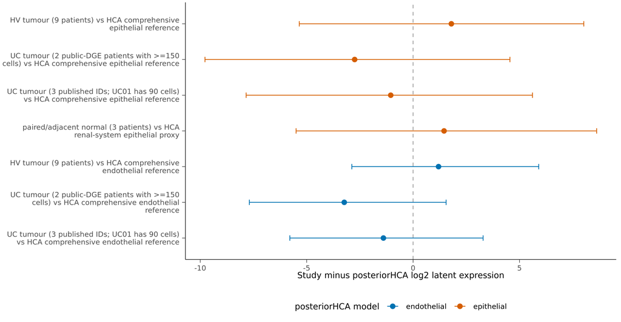

Cohort-level TM4SF1 contrasts. Positive values indicate higher expression in the study group than the model-aligned posteriorHCA comparator. Normal-labelled, 10x3-supported posteriorHCA scale. Full-width panel (183 mm).

```r
cohort_plot_data <- cohort_contrasts |>
  filter(
    study_group != "paired-normal epithelial (>=20 cells)" |
      cell_type == "epithelial"
  ) |>
  mutate(
    study_label = recode(
      study_group,
      "HV tumour epithelial" = "HV tumour (9 patients)",
      "UC tumour epithelial (2 public-DGE >=150)" =
        "UC tumour (2 public-DGE patients with >=150 cells)",
      "UC tumour epithelial (3 published IDs)" =
        "UC tumour (3 published IDs; UC01 has 90 cells)",
      "paired-normal epithelial (>=20 cells)" =
        "paired/adjacent normal (3 patients)"
    ),
    reference_label = case_when(
      str_detect(comparator, "renal-system") ~
        "HCA renal-system epithelial proxy",
      cell_type == "epithelial" ~ "HCA comprehensive epithelial reference",
      TRUE ~ "HCA comprehensive endothelial reference"
    ),
    comparison = str_wrap(paste(study_label, "vs", reference_label), 48),
    comparison = factor(comparison, levels = rev(unique(comparison)))
  )

cohort_plot <- ggplot(cohort_plot_data, aes(estimate_log2, comparison, colour = cell_type)) +
  geom_vline(xintercept = 0, linetype = 2, colour = col_other, linewidth = 0.25) +
  geom_errorbar(
    aes(xmin = lower_log2, xmax = upper_log2),
    orientation = "y", width = 0.15, linewidth = 0.3
  ) +
  geom_point(size = 1.5) +
  scale_x_continuous(labels = label_drop_leading_zero()) +
  scale_colour_manual(values = colmap_cell, name = "posteriorHCA model") +
  labs(x = "Study minus posteriorHCA log2 latent expression", y = NULL) +
  theme_multipanel

save_figure(
  cohort_plot, "05_TM4SF1_cohort_vs_posteriorHCA_logmu",
  panel_mm$full["w"], panel_mm$full["h"]
)
cohort_plot
```

The three-sample paired/adjacent-normal result is a **diagnostic calibration check**, not a healthy-control effect estimate or a matched-pair analysis. A material shift from the posteriorHCA renal proxy can arise from adjacent-tissue biology, bladder-versus-kidney aggregation, platform composition or study effects. Tumour-versus-HCA differences should therefore be read as modular cross-study contrasts rather than a jointly fitted causal effect.

# 5. A reusable threshold contract

The report defines the screening threshold separately for each posteriorHCA cell-type model:

$$T_c = Q_{q}\!\left\{ \log \mu_{\mathrm{HV},c}^{(b)} \right\}$$

where $q =$ 5% and $c$ is the posteriorHCA model, and the distribution is the nine-patient HV tumour-epithelial Bayesian bootstrap after alignment to that model’s TMMwsp reference. A supported Normal-labelled profile qualifies as a prototype candidate when

$$P\!\left( \log \mu_{\mathrm{Normal},c} \geq T_c \mid \mathrm{data} \right) \geq p_{\min}$$

with $p_{\min} =$ 80%. The selected $q$ is a lower posterior quantile of uncertainty in the nine-patient cohort-location estimator. It is not a quantile of patient expression, a minimum antigen-positive level, or a biological or clinical toxicity threshold. Both the quantile and probability are report parameters, not hidden constants.

```r
threshold_registry |>
  transmute(
    cell_type_model,
    normalization_reference,
    threshold_quantile,
    threshold_log_mu = round(threshold_log_mu, 3),
    alert_probability_cutoff,
    minimum_donor_keys,
    model_ready,
    diagnostic_gate,
    analysis_version
  ) |>
  kable(caption = "Model-specific TM4SF1 threshold registry.")
```

Model-specific TM4SF1 threshold registry.

| cell_type_model | normalization_reference | threshold_quantile | threshold_log_mu | alert_probability_cutoff | minimum_donor_keys | model_ready | diagnostic_gate | analysis_version |
| --- | --- | --- | --- | --- | --- | --- | --- | --- |
| epithelial | 04e410cbab17c7d05877161100a5d1e1___epithelial | 0.05 | 8.367 | 0.8 | 10 | FALSE | Rhat<=1.01; bulk/tail ESS>=400; zero divergences | tm4sf1-logmu-v9-design-standardised-v2.2.1-2026-08-18 |
| endothelial | e9a38836dc09755c74363eec65317e6f___endothelial | 0.05 | 6.071 | 0.8 | 10 | FALSE | Rhat<=1.01; bulk/tail ESS>=400; zero divergences | tm4sf1-logmu-v9-design-standardised-v2.2.1-2026-08-18 |

The prototype exceedance-probability and donor-support cutoffs are screening choices, so their effect is reported rather than hidden:

```r
rule_sensitivity |>
  mutate(
    threshold_quantile = percent(threshold_quantile, accuracy = 1),
    probability_rule = paste0(
      "candidates at P>=",
      percent(alert_probability_cutoff, accuracy = 1)
    )
  ) |>
  select(
    cell_type, model_ready, threshold_quantile, threshold_log_mu,
    minimum_donor_keys, supported_tissues, probability_rule,
    prototype_tissue_candidates
  ) |>
  pivot_wider(
    names_from = probability_rule,
    values_from = prototype_tissue_candidates
  ) |>
  kable(
    caption = paste(
      "Number of prototype tissue candidates under alternative HV-anchor",
      "quantiles, support rules and posterior-probability cutoffs."
    )
  )
```

Number of prototype tissue candidates under alternative HV-anchor quantiles, support rules and posterior-probability cutoffs.

| cell_type | model_ready | threshold_quantile | threshold_log_mu | minimum_donor_keys | supported_tissues | candidates at P>=50% | candidates at P>=80% | candidates at P>=95% |
| --- | --- | --- | --- | --- | --- | --- | --- | --- |
| epithelial | FALSE | 1% | 7.957641 | 5 | 10 | 4 | 0 | 0 |
| epithelial | FALSE | 1% | 7.957641 | 10 | 8 | 3 | 0 | 0 |
| epithelial | FALSE | 1% | 7.957641 | 20 | 4 | 1 | 0 | 0 |
| epithelial | FALSE | 5% | 8.367083 | 5 | 10 | 1 | 0 | 0 |
| epithelial | FALSE | 5% | 8.367083 | 10 | 8 | 1 | 0 | 0 |
| epithelial | FALSE | 5% | 8.367083 | 20 | 4 | 1 | 0 | 0 |
| epithelial | FALSE | 10% | 8.532771 | 5 | 10 | 1 | 0 | 0 |
| epithelial | FALSE | 10% | 8.532771 | 10 | 8 | 1 | 0 | 0 |
| epithelial | FALSE | 10% | 8.532771 | 20 | 4 | 1 | 0 | 0 |
| endothelial | FALSE | 1% | 5.664328 | 5 | 14 | 7 | 1 | 0 |
| endothelial | FALSE | 1% | 5.664328 | 10 | 12 | 5 | 1 | 0 |
| endothelial | FALSE | 1% | 5.664328 | 20 | 10 | 4 | 0 | 0 |
| endothelial | FALSE | 5% | 6.070556 | 5 | 14 | 5 | 1 | 0 |
| endothelial | FALSE | 5% | 6.070556 | 10 | 12 | 4 | 1 | 0 |
| endothelial | FALSE | 5% | 6.070556 | 20 | 10 | 3 | 0 | 0 |
| endothelial | FALSE | 10% | 6.246990 | 5 | 14 | 5 | 1 | 0 |
| endothelial | FALSE | 10% | 6.246990 | 10 | 12 | 4 | 1 | 0 |
| endothelial | FALSE | 10% | 6.246990 | 20 | 10 | 3 | 0 | 0 |

The raw `log(mu)` cutoff is reusable only with the recorded model store, feature, reference sample, assay policy, offset-zero convention and new-study random-effect policy. Across a different posteriorHCA release or cell-type model, the study counts must be realigned and $T_c$ recalibrated. The estimand and recomputation procedure are portable; numerical log2 ratios, exceedance probabilities and cutoffs must be recomputed for every model or baseline release.

# 6. Standardised tissue baselines and demographic marginals

Demographic outputs are **standardised marginal predictions** over the biologically admissible target covariate space, not raw observed-profile averages. The target grid is constructed from prespecified admissible levels, not only from observed atlas profiles; admissible but unobserved combinations are predicted via the posteriorHCA model and flagged as extrapolations.

Tissue rows marginalise admissible sex, age and ethnicity with nested equal weights. Tissue × sex is reported only where both sexes are biologically meaningful; sex-specific tissues report a single tissue baseline only.

A tissue-demographic result must contain at least 10 distinct dataset × donor keys across its contributing cells before it can qualify as an ungated prototype candidate. Observed-weight coverage ($C_\mathrm{obs}$) and well-supported coverage ($C_k$ with $k = 3$) quantify empirical support independently of the overlap probability. If a profile has strong overlap but limited empirical support, it is labelled a model-predicted overlap candidate with limited empirical support rather than deleted. `Other/Unknown` ethnicity is excluded from the target grid.

## Tissue and cell type

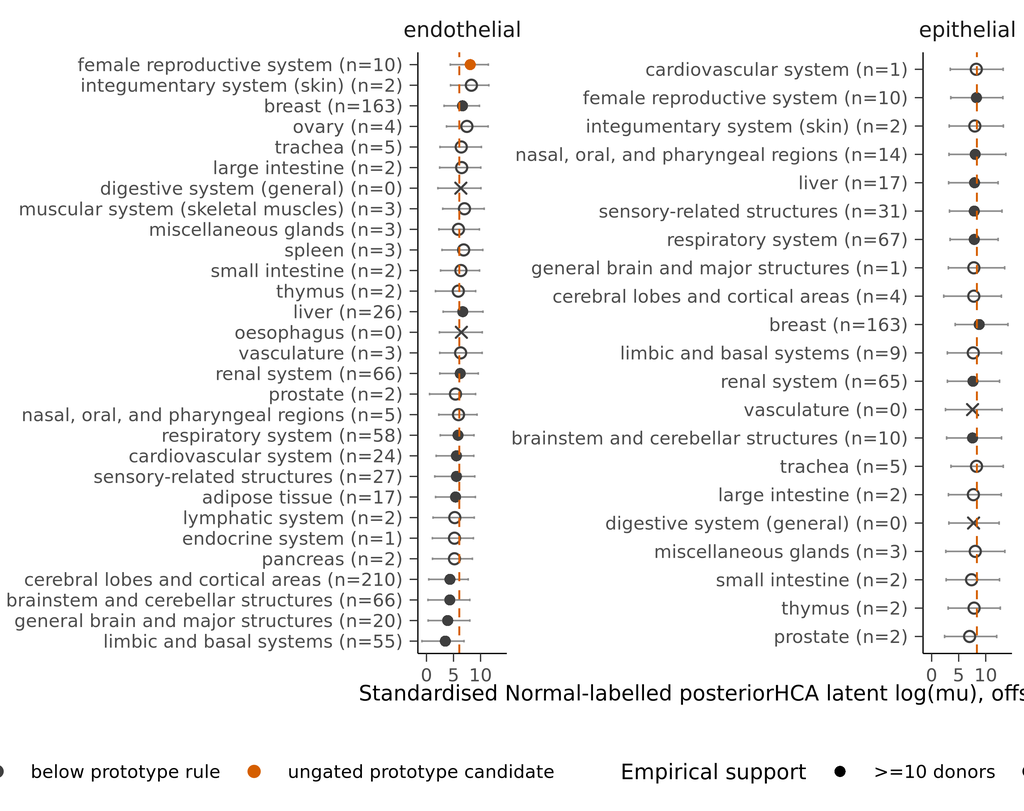

All biologically admissible tissue baselines. Point shape indicates empirical support: filled = ≥10 donor keys (supported), open circle = 1–9 donors, cross = zero donors (pure extrapolation). Colour indicates candidate status. The ≥10-donor rule gates candidate qualification, not display.

```r
tissue_plot_data <- profile_summary |>
  filter(dimension == "tissue") |>
  group_by(cell_type) |>
  mutate(tissue_rank = rank(-median_log_mu, ties.method = "first")) |>
  ungroup() |>
  mutate(
    support_level = case_when(
      n_unique_donor_keys >= 10L ~ ">=10 donors",
      n_unique_donor_keys >= 1L ~ "1-9 donors",
      TRUE ~ "0 donors (extrapolation)"
    ),
    support_level = factor(support_level, levels = c(
      ">=10 donors", "1-9 donors", "0 donors (extrapolation)"
    )),
    tissue_label = paste0(tissue_groups, " (n=", n_unique_donor_keys, ")"),
    tissue_label = reorder(tissue_label, median_log_mu)
  )

tissue_plot <- ggplot(
  tissue_plot_data,
  aes(median_log_mu, tissue_label,
      colour = prototype_overlap_candidate, shape = support_level)
) +
  geom_errorbar(
    aes(xmin = lower_log_mu, xmax = upper_log_mu),
    orientation = "y", width = 0.12, linewidth = 0.25, colour = col_other
  ) +
  geom_point(size = 1.4) +
  geom_vline(aes(xintercept = threshold_log_mu), linetype = 2, colour = col_hv, linewidth = 0.3) +
  facet_wrap(~ cell_type, scales = "free_y") +
  scale_x_continuous(labels = label_drop_leading_zero()) +
  scale_colour_manual(
    values = c(`TRUE` = col_candidate, `FALSE` = col_dark),
    labels = c(`TRUE` = "ungated prototype candidate", `FALSE` = "below prototype rule"),
    name = NULL
  ) +
  scale_shape_manual(
    values = c(">=10 donors" = 16, "1-9 donors" = 1, "0 donors (extrapolation)" = 4),
    name = "Empirical support"
  ) +
  labs(x = "Standardised Normal-labelled posteriorHCA latent log(mu), offset 0", y = NULL) +
  theme_multipanel

save_figure(
  tissue_plot, "06_posteriorHCA_TM4SF1_tissue_profiles",
  panel_mm$lg["w"], panel_mm$lg["h"]
)
tissue_plot
```

## Standardised sex marginals within tissue (both-sex tissues only)

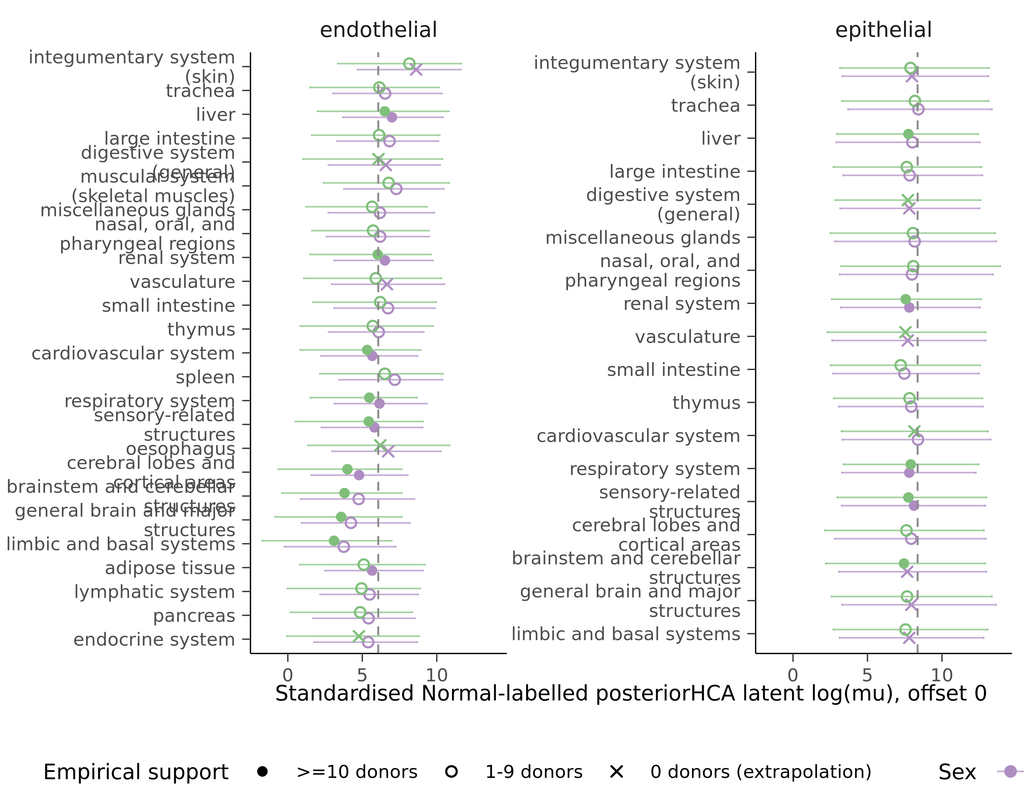

All biologically admissible tissue × sex target predictions are shown. Point shape indicates empirical support: filled circle = ≥10 donor keys, open circle = 1–9 donors, cross = zero donors (model extrapolation). Colour encodes sex. The ≥10-donor rule is used for candidate qualification, not for display.

```r
sex_plot_data <- profile_summary |>
  filter(dimension == "tissue_sex") |>
  mutate(
    support_level = case_when(
      n_unique_donor_keys >= 10L ~ ">=10 donors",
      n_unique_donor_keys >= 1L ~ "1-9 donors",
      TRUE ~ "0 donors (extrapolation)"
    ),
    support_level = factor(support_level, levels = c(
      ">=10 donors", "1-9 donors", "0 donors (extrapolation)"
    )),
    tissue_groups = str_wrap(tissue_groups, 24),
    tissue_groups = reorder(tissue_groups, median_log_mu)
  )

sex_plot <- ggplot(sex_plot_data, aes(
  median_log_mu, tissue_groups, colour = sex, shape = support_level
)) +
  geom_errorbar(
    aes(xmin = lower_log_mu, xmax = upper_log_mu),
    orientation = "y", width = 0.12, linewidth = 0.25,
    position = position_dodge(width = 0.5),
    alpha = 0.7
  ) +
  geom_point(position = position_dodge(width = 0.5), size = 1.3) +
  geom_vline(aes(xintercept = threshold_log_mu), linetype = 2, colour = col_other, linewidth = 0.3) +
  facet_wrap(~ cell_type, scales = "free_y") +
  scale_x_continuous(labels = label_drop_leading_zero()) +
  scale_colour_manual(values = colmap_sex, name = "Sex") +
  scale_shape_manual(
    values = c(">=10 donors" = 16, "1-9 donors" = 1, "0 donors (extrapolation)" = 4),
    name = "Empirical support"
  ) +
  labs(x = "Standardised Normal-labelled posteriorHCA latent log(mu), offset 0", y = NULL) +
  theme_multipanel

save_figure(
  sex_plot, "07_posteriorHCA_TM4SF1_tissue_by_sex",
  panel_mm$lg["w"], panel_mm$lg["h"]
)
sex_plot
```

## Standardised age-decade marginals within tissue

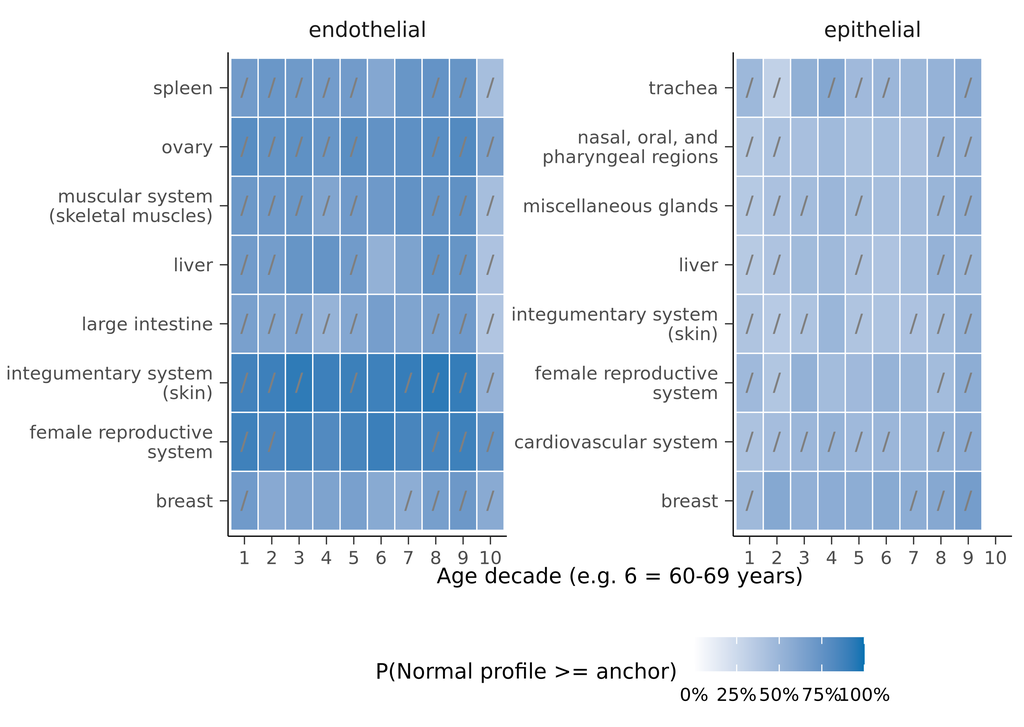

All biologically admissible tissue × age-decade target predictions. Tile colour encodes overlap probability; outlined tiles pass the prototype overlap rule. Hatched tiles (diagonal line) have zero direct donor support (model extrapolation). The ≥10-donor rule is used for candidate qualification, not for display.

```r
top_tissues <- profile_summary |>
  filter(dimension == "tissue") |>
  group_by(cell_type) |>
  slice_max(median_log_mu, n = 8, with_ties = FALSE) |>
  ungroup() |>
  select(cell_type, tissue_groups)

candidate_tissues <- profile_summary |>
  filter(prototype_overlap_candidate, !is.na(tissue_groups)) |>
  select(cell_type, tissue_groups)

display_tissues <- bind_rows(top_tissues, candidate_tissues) |>
  distinct()

age_plot_data <- profile_summary |>
  filter(dimension == "tissue_age") |>
  inner_join(display_tissues, by = c("cell_type", "tissue_groups")) |>
  mutate(
    age_decade = factor(
      age_decade,
      levels = as.character(sort(unique(as.integer(age_decade))))
    ),
    tissue_groups = str_wrap(tissue_groups, 24),
    is_extrapolated = n_unique_donor_keys == 0L
  )

age_plot <- ggplot(
  age_plot_data,
  aes(age_decade, tissue_groups, fill = probability_above_threshold)
) +
  geom_tile(colour = "white", linewidth = 0.2) +
  geom_point(
    data = filter(age_plot_data, is_extrapolated),
    shape = 47, colour = "grey50", size = 2.5
  ) +
  geom_point(
    data = filter(age_plot_data, prototype_overlap_candidate),
    shape = 21, fill = NA, colour = col_dark, size = 1.6, stroke = 0.4
  ) +
  facet_wrap(~ cell_type, scales = "free_y") +
  scale_fill_gradient(
    low = "white", high = col_uc,
    limits = c(0, 1), labels = label_percent(),
    name = "P(Normal profile >= anchor)"
  ) +
  labs(x = "Age decade (e.g. 6 = 60-69 years)", y = NULL) +
  theme_multipanel

save_figure(
  age_plot, "08_posteriorHCA_TM4SF1_tissue_by_age",
  panel_mm$heatmap["w"], panel_mm$heatmap["h"]
)
age_plot
```

## Standardised ethnicity marginals within tissue

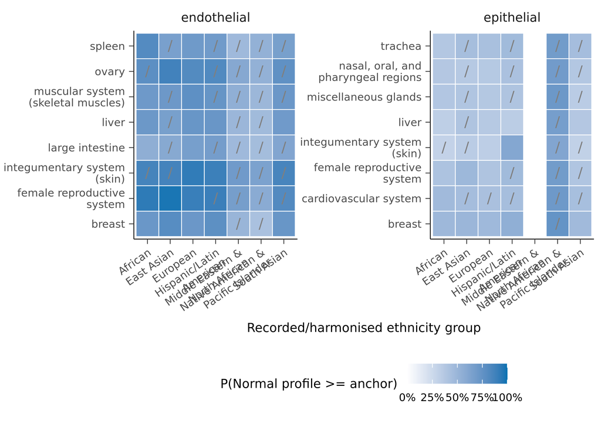

All biologically admissible tissue × ethnicity target predictions. Tile colour encodes overlap probability; outlined tiles pass the prototype overlap rule. Slash-marked tiles have zero direct donor support (model extrapolation). The ≥10-donor rule is used for candidate qualification, not for display.

```r
ethnicity_plot_data <- profile_summary |>
  filter(dimension == "tissue_ethnicity") |>
  inner_join(display_tissues, by = c("cell_type", "tissue_groups")) |>
  mutate(
    tissue_groups = str_wrap(tissue_groups, 24),
    ethnicity_groups = str_wrap(ethnicity_groups, 18),
    is_extrapolated = n_unique_donor_keys == 0L
  )

ethnicity_plot <- ggplot(
  ethnicity_plot_data,
  aes(ethnicity_groups, tissue_groups, fill = probability_above_threshold)
) +
  geom_tile(colour = "white", linewidth = 0.2) +
  geom_point(
    data = filter(ethnicity_plot_data, is_extrapolated),
    shape = 47, colour = "grey50", size = 2.5
  ) +
  geom_point(
    data = filter(ethnicity_plot_data, prototype_overlap_candidate),
    shape = 21, fill = NA, colour = col_dark, size = 1.6, stroke = 0.4
  ) +
  facet_wrap(~ cell_type, scales = "free_y") +
  scale_fill_gradient(
    low = "white", high = col_uc,
    limits = c(0, 1), labels = label_percent(),
    name = "P(Normal profile >= anchor)"
  ) +
  labs(x = "Recorded/harmonised ethnicity group", y = NULL) +
  theme_multipanel +
  theme(
    axis.text.x = element_text(angle = 35, hjust = 1),
    plot.margin = margin(2, 4, 8, 2)
  )

save_figure(
  ethnicity_plot, "09_posteriorHCA_TM4SF1_tissue_by_ethnicity",
  panel_mm$heatmap["w"], panel_mm$heatmap["h"]
)
ethnicity_plot
```

## Ungated prototype candidates for follow-up

```r
candidate_table <- profile_summary |>
  filter(
    prototype_overlap_candidate,
    dimension %in% c("tissue", "tissue_sex", "tissue_age", "tissue_ethnicity")
  ) |>
  arrange(cell_type, dimension, desc(probability_above_threshold)) |>
  transmute(
    cell_type,
    dimension,
    tissue = tissue_groups,
    sex,
    age_decade,
    ethnicity = ethnicity_groups,
    donor_keys = n_unique_donor_keys,
    C_obs = round(C_obs, 2),
    C_k = round(C_k, 2),
    extrap_wt = round(extrapolation_weight, 2),
    median_log_mu = round(median_log_mu, 2),
    log2_vs_HV = round(estimate_log2_vs_hv, 2),
    P_above_threshold = percent(probability_above_threshold, accuracy = 0.1),
    P_at_least_random_HV = percent(probability_hca_ge_random_hv, accuracy = 0.1),
    support_label = case_when(
      C_obs >= 0.8 ~ "well supported",
      C_obs >= 0.5 ~ "moderate support",
      TRUE ~ "limited empirical support"
    )
  )

head(candidate_table, 40) |>
  kable(
    caption = paste(
      "First 40 supported prototype overlap candidates, ungated by model",
      "readiness. The full machine-readable table is written to results/."
    )
  )
```

First 40 supported prototype overlap candidates, ungated by model readiness. The full machine-readable table is written to results/.

| cell_type | dimension | tissue | sex | age_decade | ethnicity | donor_keys | C_obs | C_k | extrap_wt | median_log_mu | log2_vs_HV | P_above_threshold | P_at_least_random_HV | support_label |
| --- | --- | --- | --- | --- | --- | --- | --- | --- | --- | --- | --- | --- | --- | --- |
| endothelial | tissue | female reproductive system | NA | NA | NA | 10 | 0.1 | 0.01 | 0.9 | 8.09 | 1.95 | 86.8% | 75.8% | limited empirical support |

The tissue, tissue × sex (where reported), tissue × age and tissue × ethnicity rows are nested views of the same standardised baseline framework; they should not be counted as independent safety findings.

## Baseline audit (v1 → v2 → v2.1 comparison)

```r
baseline_comparison |>
  mutate(across(where(is.numeric), ~ round(.x, 3))) |>
  kable(
    caption = paste(
      "Tissue-level baseline comparison across all three versions.",
      "v1 = observed-profile; v2 = first design-standardised;",
      "v2.1 = corrected admissibility with support diagnostics."
    )
  )
```

Tissue-level baseline comparison across all three versions. v1 = observed-profile; v2 = first design-standardised; v2.1 = corrected admissibility with support diagnostics.

| cell_type | tissue_groups | v2.1_median_log_mu | v2.1_P_above | v2.1_candidate | v2.1_donors | v2.1_C_obs | v2.1_C_k | v2.1_extrapolation_weight | v2_median_log_mu | v2_P_above | v2_candidate | v2_donors | v1_median_log_mu | v1_P_above | v1_candidate | v1_donors | candidate_status |
| --- | --- | --- | --- | --- | --- | --- | --- | --- | --- | --- | --- | --- | --- | --- | --- | --- | --- |
| epithelial | brainstem and cerebellar structures | 7.563 | 0.350 | FALSE | 10 | 0.019 | 0.009 | 0.981 | 7.057 | 0.275 | FALSE | 10 | 7.108 | 0.292 | FALSE | 10 | non_candidate |
| epithelial | breast | 8.798 | 0.568 | FALSE | 163 | 0.204 | 0.111 | 0.796 | 8.236 | 0.482 | FALSE | 163 | 8.154 | 0.475 | FALSE | 211 | non_candidate |
| epithelial | female reproductive system | 8.286 | 0.488 | FALSE | 10 | 0.130 | 0.019 | 0.870 | 7.894 | 0.438 | FALSE | 10 | 7.865 | 0.428 | FALSE | 10 | non_candidate |
| epithelial | liver | 7.936 | 0.422 | FALSE | 17 | 0.083 | 0.028 | 0.917 | 7.550 | 0.370 | FALSE | 17 | 7.573 | 0.375 | FALSE | 35 | non_candidate |
| epithelial | nasal, oral, and pharyngeal regions | 8.052 | 0.442 | FALSE | 14 | 0.074 | 0.019 | 0.926 | 7.535 | 0.352 | FALSE | 14 | 7.602 | 0.362 | FALSE | 14 | non_candidate |
| epithelial | renal system | 7.641 | 0.398 | FALSE | 65 | 0.157 | 0.093 | 0.843 | 7.066 | 0.288 | FALSE | 65 | 7.160 | 0.298 | FALSE | 90 | non_candidate |
| epithelial | respiratory system | 7.880 | 0.415 | FALSE | 67 | 0.222 | 0.074 | 0.778 | 7.787 | 0.415 | FALSE | 67 | 7.746 | 0.412 | FALSE | 98 | non_candidate |
| epithelial | sensory-related structures | 7.885 | 0.435 | FALSE | 31 | 0.120 | 0.046 | 0.880 | 7.602 | 0.375 | FALSE | 31 | 7.420 | 0.338 | FALSE | 40 | non_candidate |
| endothelial | adipose tissue | 5.373 | 0.345 | FALSE | 17 | 0.071 | 0.007 | 0.929 | 5.894 | 0.445 | FALSE | 17 | 5.882 | 0.442 | FALSE | 21 | non_candidate |
| endothelial | brainstem and cerebellar structures | 4.317 | 0.192 | FALSE | 66 | 0.057 | 0.029 | 0.943 | 4.671 | 0.185 | FALSE | 66 | 4.507 | 0.145 | FALSE | 66 | non_candidate |
| endothelial | breast | 6.661 | 0.645 | FALSE | 163 | 0.157 | 0.086 | 0.843 | 6.813 | 0.703 | FALSE | 163 | 6.871 | 0.718 | FALSE | 211 | non_candidate |
| endothelial | cardiovascular system | 5.539 | 0.405 | FALSE | 24 | 0.086 | 0.029 | 0.914 | 6.252 | 0.550 | FALSE | 24 | 6.474 | 0.598 | FALSE | 27 | non_candidate |
| endothelial | cerebral lobes and cortical areas | 4.342 | 0.150 | FALSE | 210 | 0.100 | 0.050 | 0.900 | 4.674 | 0.190 | FALSE | 210 | 4.622 | 0.182 | FALSE | 238 | non_candidate |
| endothelial | female reproductive system | 8.090 | 0.868 | TRUE | 10 | 0.100 | 0.014 | 0.900 | 8.197 | 0.915 | TRUE | 10 | 8.190 | 0.915 | TRUE | 10 | retained from v1 |
| endothelial | general brain and major structures | 3.927 | 0.122 | FALSE | 20 | 0.050 | 0.029 | 0.950 | 4.343 | 0.115 | FALSE | 20 | 4.376 | 0.120 | FALSE | 20 | non_candidate |
| endothelial | limbic and basal systems | 3.481 | 0.090 | FALSE | 55 | 0.050 | 0.014 | 0.950 | 3.698 | 0.072 | FALSE | 55 | 3.698 | 0.055 | FALSE | 58 | non_candidate |
| endothelial | liver | 6.712 | 0.637 | FALSE | 26 | 0.064 | 0.021 | 0.936 | 7.189 | 0.752 | FALSE | 26 | 6.924 | 0.718 | FALSE | 51 | non_candidate |
| endothelial | renal system | 6.240 | 0.542 | FALSE | 66 | 0.121 | 0.071 | 0.879 | 6.578 | 0.642 | FALSE | 66 | 6.594 | 0.642 | FALSE | 88 | non_candidate |
| endothelial | respiratory system | 5.830 | 0.430 | FALSE | 58 | 0.164 | 0.043 | 0.836 | 6.257 | 0.530 | FALSE | 58 | 6.385 | 0.580 | FALSE | 85 | non_candidate |
| endothelial | sensory-related structures | 5.539 | 0.395 | FALSE | 27 | 0.071 | 0.036 | 0.929 | 6.148 | 0.515 | FALSE | 27 | 6.423 | 0.598 | FALSE | 33 | non_candidate |

```r
candidate_transition |>
  filter(transition != "none") |>
  kable(
    caption = paste(
      "Prototype overlap candidates retained, lost or newly appeared",
      "across v1 → v2 → v2.1."
    )
  )
```

Prototype overlap candidates retained, lost or newly appeared across v1 → v2 → v2.1.

| key | in_v1 | in_v2 | in_v2.1 | transition |
| --- | --- | --- | --- | --- |
| endothelial \| tissue \| female reproductive system \| NA \| NA \| NA | TRUE | TRUE | TRUE | retained |
| endothelial \| tissue \| integumentary system (skin) \| NA \| NA \| NA | TRUE | FALSE | FALSE | disappeared |
| endothelial \| tissue_sex \| female reproductive system \| female \| NA \| NA | TRUE | FALSE | FALSE | disappeared |
| endothelial \| tissue_sex \| integumentary system (skin) \| male \| NA \| NA | TRUE | FALSE | FALSE | disappeared |

```r
marginalisation_weights_all |>
  group_by(cell_type, tissue_groups) |>
  summarise(
    n_target_cells = n(),
    n_observed = sum(direct_empirical_support),
    n_extrapolated = sum(requires_extrapolation),
    weight_sum = sum(marginal_weight),
    sex_levels = paste(sort(unique(sex)), collapse = ", "),
    .groups = "drop"
  ) |>
  kable(
    caption = paste(
      "Marginalisation weight summary per tissue.",
      "n_target_cells is the full admissible design grid;",
      "n_extrapolated cells lack direct atlas support."
    )
  )
```

Marginalisation weight summary per tissue. n_target_cells is the full admissible design grid; n_extrapolated cells lack direct atlas support.

| cell_type | tissue_groups | n_target_cells | n_observed | n_extrapolated | weight_sum | sex_levels |
| --- | --- | --- | --- | --- | --- | --- |
| endothelial | adipose tissue | 140 | 10 | 130 | 1 | female, male |
| endothelial | brainstem and cerebellar structures | 140 | 8 | 132 | 1 | female, male |
| endothelial | breast | 70 | 11 | 59 | 1 | female |
| endothelial | cardiovascular system | 140 | 12 | 128 | 1 | female, male |
| endothelial | cerebral lobes and cortical areas | 140 | 14 | 126 | 1 | female, male |
| endothelial | digestive system (general) | 140 | 0 | 140 | 1 | female, male |
| endothelial | endocrine system | 140 | 1 | 139 | 1 | female, male |
| endothelial | female reproductive system | 70 | 7 | 63 | 1 | female |
| endothelial | general brain and major structures | 140 | 7 | 133 | 1 | female, male |
| endothelial | integumentary system (skin) | 140 | 2 | 138 | 1 | female, male |
| endothelial | large intestine | 140 | 2 | 138 | 1 | female, male |
| endothelial | limbic and basal systems | 140 | 7 | 133 | 1 | female, male |
| endothelial | liver | 140 | 9 | 131 | 1 | female, male |
| endothelial | lymphatic system | 140 | 2 | 138 | 1 | female, male |
| endothelial | miscellaneous glands | 140 | 3 | 137 | 1 | female, male |
| endothelial | muscular system (skeletal muscles) | 140 | 3 | 137 | 1 | female, male |
| endothelial | nasal, oral, and pharyngeal regions | 140 | 4 | 136 | 1 | female, male |
| endothelial | oesophagus | 140 | 0 | 140 | 1 | female, male |
| endothelial | ovary | 70 | 3 | 67 | 1 | female |
| endothelial | pancreas | 140 | 2 | 138 | 1 | female, male |
| endothelial | prostate | 70 | 2 | 68 | 1 | male |
| endothelial | renal system | 140 | 17 | 123 | 1 | female, male |
| endothelial | respiratory system | 140 | 23 | 117 | 1 | female, male |
| endothelial | sensory-related structures | 140 | 10 | 130 | 1 | female, male |
| endothelial | small intestine | 140 | 2 | 138 | 1 | female, male |
| endothelial | spleen | 140 | 3 | 137 | 1 | female, male |
| endothelial | thymus | 140 | 2 | 138 | 1 | female, male |
| endothelial | trachea | 140 | 4 | 136 | 1 | female, male |
| endothelial | vasculature | 140 | 2 | 138 | 1 | female, male |
| epithelial | brainstem and cerebellar structures | 108 | 2 | 106 | 1 | female, male |
| epithelial | breast | 54 | 11 | 43 | 1 | female |
| epithelial | cardiovascular system | 108 | 1 | 107 | 1 | female, male |
| epithelial | cerebral lobes and cortical areas | 108 | 2 | 106 | 1 | female, male |
| epithelial | digestive system (general) | 108 | 0 | 108 | 1 | female, male |
| epithelial | female reproductive system | 54 | 7 | 47 | 1 | female |
| epithelial | general brain and major structures | 108 | 1 | 107 | 1 | female, male |
| epithelial | integumentary system (skin) | 108 | 2 | 106 | 1 | female, male |
| epithelial | large intestine | 108 | 2 | 106 | 1 | female, male |
| epithelial | limbic and basal systems | 108 | 2 | 106 | 1 | female, male |
| epithelial | liver | 108 | 9 | 99 | 1 | female, male |
| epithelial | miscellaneous glands | 108 | 3 | 105 | 1 | female, male |
| epithelial | nasal, oral, and pharyngeal regions | 108 | 8 | 100 | 1 | female, male |
| epithelial | prostate | 54 | 2 | 52 | 1 | male |
| epithelial | renal system | 108 | 17 | 91 | 1 | female, male |
| epithelial | respiratory system | 108 | 24 | 84 | 1 | female, male |
| epithelial | sensory-related structures | 108 | 13 | 95 | 1 | female, male |
| epithelial | small intestine | 108 | 2 | 106 | 1 | female, male |
| epithelial | thymus | 108 | 2 | 106 | 1 | female, male |
| epithelial | trachea | 108 | 4 | 104 | 1 | female, male |
| epithelial | vasculature | 108 | 0 | 108 | 1 | female, male |

```r
female_repro_audit |>
  select(
    cell_type, sex, age_decade, ethnicity_groups,
    n_donor_keys, direct_empirical_support, requires_extrapolation,
    marginal_weight, weight_rule
  ) |>
  kable(
    caption = paste(
      "Female reproductive system marginalisation weights (v2.1).",
      "Male sex is structurally excluded. Extrapolated cells are flagged."
    )
  )
```

Female reproductive system marginalisation weights (v2.1). Male sex is structurally excluded. Extrapolated cells are flagged.

| cell_type | sex | age_decade | ethnicity_groups | n_donor_keys | direct_empirical_support | requires_extrapolation | marginal_weight | weight_rule |
| --- | --- | --- | --- | --- | --- | --- | --- | --- |
| endothelial | female | 1 | African | 0 | FALSE | TRUE | 0.0142857 | equal sex (1/1) × equal age (1/10) × equal ethnicity (1/7) |
| endothelial | female | 1 | East Asian | 0 | FALSE | TRUE | 0.0142857 | equal sex (1/1) × equal age (1/10) × equal ethnicity (1/7) |
| endothelial | female | 1 | European | 0 | FALSE | TRUE | 0.0142857 | equal sex (1/1) × equal age (1/10) × equal ethnicity (1/7) |
| endothelial | female | 1 | Hispanic/Latin American | 0 | FALSE | TRUE | 0.0142857 | equal sex (1/1) × equal age (1/10) × equal ethnicity (1/7) |
| endothelial | female | 1 | Middle Eastern & North African | 0 | FALSE | TRUE | 0.0142857 | equal sex (1/1) × equal age (1/10) × equal ethnicity (1/7) |
| endothelial | female | 1 | Native American & Pacific Islander | 0 | FALSE | TRUE | 0.0142857 | equal sex (1/1) × equal age (1/10) × equal ethnicity (1/7) |
| endothelial | female | 1 | South Asian | 0 | FALSE | TRUE | 0.0142857 | equal sex (1/1) × equal age (1/10) × equal ethnicity (1/7) |
| endothelial | female | 10 | African | 0 | FALSE | TRUE | 0.0142857 | equal sex (1/1) × equal age (1/10) × equal ethnicity (1/7) |
| endothelial | female | 10 | East Asian | 0 | FALSE | TRUE | 0.0142857 | equal sex (1/1) × equal age (1/10) × equal ethnicity (1/7) |
| endothelial | female | 10 | European | 0 | FALSE | TRUE | 0.0142857 | equal sex (1/1) × equal age (1/10) × equal ethnicity (1/7) |
| endothelial | female | 10 | Hispanic/Latin American | 0 | FALSE | TRUE | 0.0142857 | equal sex (1/1) × equal age (1/10) × equal ethnicity (1/7) |
| endothelial | female | 10 | Middle Eastern & North African | 0 | FALSE | TRUE | 0.0142857 | equal sex (1/1) × equal age (1/10) × equal ethnicity (1/7) |
| endothelial | female | 10 | Native American & Pacific Islander | 0 | FALSE | TRUE | 0.0142857 | equal sex (1/1) × equal age (1/10) × equal ethnicity (1/7) |
| endothelial | female | 10 | South Asian | 0 | FALSE | TRUE | 0.0142857 | equal sex (1/1) × equal age (1/10) × equal ethnicity (1/7) |
| endothelial | female | 2 | African | 0 | FALSE | TRUE | 0.0142857 | equal sex (1/1) × equal age (1/10) × equal ethnicity (1/7) |
| endothelial | female | 2 | East Asian | 0 | FALSE | TRUE | 0.0142857 | equal sex (1/1) × equal age (1/10) × equal ethnicity (1/7) |
| endothelial | female | 2 | European | 0 | FALSE | TRUE | 0.0142857 | equal sex (1/1) × equal age (1/10) × equal ethnicity (1/7) |
| endothelial | female | 2 | Hispanic/Latin American | 0 | FALSE | TRUE | 0.0142857 | equal sex (1/1) × equal age (1/10) × equal ethnicity (1/7) |
| endothelial | female | 2 | Middle Eastern & North African | 0 | FALSE | TRUE | 0.0142857 | equal sex (1/1) × equal age (1/10) × equal ethnicity (1/7) |
| endothelial | female | 2 | Native American & Pacific Islander | 0 | FALSE | TRUE | 0.0142857 | equal sex (1/1) × equal age (1/10) × equal ethnicity (1/7) |
| endothelial | female | 2 | South Asian | 0 | FALSE | TRUE | 0.0142857 | equal sex (1/1) × equal age (1/10) × equal ethnicity (1/7) |
| endothelial | female | 3 | African | 0 | FALSE | TRUE | 0.0142857 | equal sex (1/1) × equal age (1/10) × equal ethnicity (1/7) |
| endothelial | female | 3 | East Asian | 0 | FALSE | TRUE | 0.0142857 | equal sex (1/1) × equal age (1/10) × equal ethnicity (1/7) |
| endothelial | female | 3 | European | 1 | TRUE | FALSE | 0.0142857 | equal sex (1/1) × equal age (1/10) × equal ethnicity (1/7) |
| endothelial | female | 3 | Hispanic/Latin American | 0 | FALSE | TRUE | 0.0142857 | equal sex (1/1) × equal age (1/10) × equal ethnicity (1/7) |
| endothelial | female | 3 | Middle Eastern & North African | 0 | FALSE | TRUE | 0.0142857 | equal sex (1/1) × equal age (1/10) × equal ethnicity (1/7) |
| endothelial | female | 3 | Native American & Pacific Islander | 0 | FALSE | TRUE | 0.0142857 | equal sex (1/1) × equal age (1/10) × equal ethnicity (1/7) |
| endothelial | female | 3 | South Asian | 0 | FALSE | TRUE | 0.0142857 | equal sex (1/1) × equal age (1/10) × equal ethnicity (1/7) |
| endothelial | female | 4 | African | 1 | TRUE | FALSE | 0.0142857 | equal sex (1/1) × equal age (1/10) × equal ethnicity (1/7) |
| endothelial | female | 4 | East Asian | 0 | FALSE | TRUE | 0.0142857 | equal sex (1/1) × equal age (1/10) × equal ethnicity (1/7) |

[output cut: 94 more lines]

The motivating respiratory-system example is checked explicitly rather than assumed:

```r
respiratory_sex <- profile_summary |>
  filter(
    dimension == "tissue_sex",
    tissue_groups == "respiratory system",
    supported
  ) |>
  transmute(
    cell_type,
    sex,
    donor_keys = n_unique_donor_keys,
    C_obs = round(C_obs, 2),
    median_log_mu = round(median_log_mu, 2),
    threshold_log_mu = round(threshold_log_mu, 2),
    P_above_threshold = percent(probability_above_threshold, accuracy = 0.1),
    prototype_candidate = prototype_overlap_candidate,
    model_ready,
    model_ready_alert = expression_overlap_alert
  )

respiratory_sex |>
  kable(caption = "Standardised respiratory-system tissue × sex marginals under v2.2.1.")
```

Standardised respiratory-system tissue × sex marginals under v2.2.1.

| cell_type | sex | donor_keys | C_obs | median_log_mu | threshold_log_mu | P_above_threshold | prototype_candidate | model_ready | model_ready_alert |
| --- | --- | --- | --- | --- | --- | --- | --- | --- | --- |
| epithelial | female | 30 | 0.20 | 7.81 | 8.37 | 41.0% | FALSE | FALSE | FALSE |
| epithelial | male | 37 | 0.24 | 7.91 | 8.37 | 42.2% | FALSE | FALSE | FALSE |
| endothelial | female | 26 | 0.16 | 6.15 | 6.07 | 51.8% | FALSE | FALSE | FALSE |
| endothelial | male | 32 | 0.17 | 5.47 | 6.07 | 36.5% | FALSE | FALSE | FALSE |

No supported respiratory-system sex profile passes the current 80% prototype-overlap rule. Model readiness is reported separately, so the present analysis supports neither a respiratory-system candidate nor a male-lung alert.

## Tissue × sex plotting audit (v2.2)

```r
sex_predictions <- profile_summary |>
  filter(dimension == "tissue_sex")

sex_audit <- sex_predictions |>
  left_join(
    tissue_sex_rules_all |>
      select(
        cell_type, tissue_groups,
        biologically_allowed_sex, analysis_allowed_sex,
        atlas_observed_sex, restriction_type, has_unobserved_target_sex
      ),
    by = c("cell_type", "tissue_groups")
  ) |>
  transmute(
    cell_type,
    tissue_groups,
    sex,
    biologically_allowed = biologically_allowed_sex,
    analysis_allowed = analysis_allowed_sex,
    atlas_observed = atlas_observed_sex,
    n_unique_donor_keys,
    supported,
    C_obs = round(C_obs, 2),
    C_k = round(C_k, 2),
    extrapolation_weight = round(extrapolation_weight, 2),
    plotted_in_figure = TRUE
  )

stopifnot(
  "sex_audit must have same rows as sex_predictions" =
    nrow(sex_audit) == nrow(sex_predictions),
  "sex_audit must be unique by cell_type × tissue × sex" =
    !anyDuplicated(sex_audit |> select(cell_type, tissue_groups, sex))
)

sex_audit |>
  head(40) |>
  kable(caption = paste(
    "Tissue × sex plotting audit (first 40 rows).",
    "Every generated tissue_sex prediction is plotted.",
    "No prediction removed because supported == FALSE.",
    "Structurally invalid combinations are absent by construction.",
    "Joined by cell_type × tissue_groups (v2.2.1 corrected)."
  ))
```

Tissue × sex plotting audit (first 40 rows). Every generated tissue_sex prediction is plotted. No prediction removed because supported == FALSE. Structurally invalid combinations are absent by construction. Joined by cell_type × tissue_groups (v2.2.1 corrected).

| cell_type | tissue_groups | sex | biologically_allowed | analysis_allowed | atlas_observed | n_unique_donor_keys | supported | C_obs | C_k | extrapolation_weight | plotted_in_figure |
| --- | --- | --- | --- | --- | --- | --- | --- | --- | --- | --- | --- |
| epithelial | brainstem and cerebellar structures | female | female, male | female, male | male | 0 | FALSE | 0.00 | 0.00 | 1.00 | TRUE |
| epithelial | brainstem and cerebellar structures | male | female, male | female, male | male | 10 | TRUE | 0.04 | 0.02 | 0.96 | TRUE |
| epithelial | cardiovascular system | female | female, male | female, male | female | 1 | FALSE | 0.02 | 0.00 | 0.98 | TRUE |
| epithelial | cardiovascular system | male | female, male | female, male | female | 0 | FALSE | 0.00 | 0.00 | 1.00 | TRUE |
| epithelial | cerebral lobes and cortical areas | female | female, male | female, male | female, male | 1 | FALSE | 0.02 | 0.00 | 0.98 | TRUE |
| epithelial | cerebral lobes and cortical areas | male | female, male | female, male | female, male | 3 | FALSE | 0.02 | 0.02 | 0.98 | TRUE |
| epithelial | digestive system (general) | female | female, male | female, male | female | 0 | FALSE | 0.00 | 0.00 | 1.00 | TRUE |
| epithelial | digestive system (general) | male | female, male | female, male | female | 0 | FALSE | 0.00 | 0.00 | 1.00 | TRUE |
| epithelial | general brain and major structures | female | female, male | female, male | male | 0 | FALSE | 0.00 | 0.00 | 1.00 | TRUE |
| epithelial | general brain and major structures | male | female, male | female, male | male | 1 | FALSE | 0.02 | 0.00 | 0.98 | TRUE |
| epithelial | integumentary system (skin) | female | female, male | female, male | female, male | 0 | FALSE | 0.00 | 0.00 | 1.00 | TRUE |
| epithelial | integumentary system (skin) | male | female, male | female, male | female, male | 2 | FALSE | 0.04 | 0.00 | 0.96 | TRUE |
| epithelial | large intestine | female | female, male | female, male | female, male | 1 | FALSE | 0.02 | 0.00 | 0.98 | TRUE |
| epithelial | large intestine | male | female, male | female, male | female, male | 1 | FALSE | 0.02 | 0.00 | 0.98 | TRUE |
| epithelial | limbic and basal systems | female | female, male | female, male | male | 0 | FALSE | 0.00 | 0.00 | 1.00 | TRUE |
| epithelial | limbic and basal systems | male | female, male | female, male | male | 9 | FALSE | 0.04 | 0.04 | 0.96 | TRUE |
| epithelial | liver | female | female, male | female, male | female, male | 7 | FALSE | 0.07 | 0.02 | 0.93 | TRUE |
| epithelial | liver | male | female, male | female, male | female, male | 10 | TRUE | 0.09 | 0.04 | 0.91 | TRUE |
| epithelial | miscellaneous glands | female | female, male | female, male | female, male | 2 | FALSE | 0.04 | 0.00 | 0.96 | TRUE |
| epithelial | miscellaneous glands | male | female, male | female, male | female, male | 1 | FALSE | 0.02 | 0.00 | 0.98 | TRUE |
| epithelial | nasal, oral, and pharyngeal regions | female | female, male | female, male | female, male | 7 | FALSE | 0.07 | 0.02 | 0.93 | TRUE |
| epithelial | nasal, oral, and pharyngeal regions | male | female, male | female, male | female, male | 7 | FALSE | 0.07 | 0.02 | 0.93 | TRUE |
| epithelial | renal system | female | female, male | female, male | female, male | 32 | TRUE | 0.19 | 0.07 | 0.81 | TRUE |
| epithelial | renal system | male | female, male | female, male | female, male | 33 | TRUE | 0.13 | 0.11 | 0.87 | TRUE |
| epithelial | respiratory system | female | female, male | female, male | female, male | 30 | TRUE | 0.20 | 0.07 | 0.80 | TRUE |
| epithelial | respiratory system | male | female, male | female, male | female, male | 37 | TRUE | 0.24 | 0.07 | 0.76 | TRUE |
| epithelial | sensory-related structures | female | female, male | female, male | female, male | 14 | TRUE | 0.11 | 0.04 | 0.89 | TRUE |
| epithelial | sensory-related structures | male | female, male | female, male | female, male | 17 | TRUE | 0.13 | 0.06 | 0.87 | TRUE |
| epithelial | small intestine | female | female, male | female, male | female, male | 1 | FALSE | 0.02 | 0.00 | 0.98 | TRUE |
| epithelial | small intestine | male | female, male | female, male | female, male | 1 | FALSE | 0.02 | 0.00 | 0.98 | TRUE |
| epithelial | thymus | female | female, male | female, male | female, male | 1 | FALSE | 0.02 | 0.00 | 0.98 | TRUE |
| epithelial | thymus | male | female, male | female, male | female, male | 1 | FALSE | 0.02 | 0.00 | 0.98 | TRUE |
| epithelial | trachea | female | female, male | female, male | female, male | 2 | FALSE | 0.04 | 0.00 | 0.96 | TRUE |
| epithelial | trachea | male | female, male | female, male | female, male | 3 | FALSE | 0.04 | 0.00 | 0.96 | TRUE |
| epithelial | vasculature | female | female, male | female, male | female | 0 | FALSE | 0.00 | 0.00 | 1.00 | TRUE |
| epithelial | vasculature | male | female, male | female, male | female | 0 | FALSE | 0.00 | 0.00 | 1.00 | TRUE |
| endothelial | adipose tissue | female | female, male | female, male | female, male | 13 | TRUE | 0.09 | 0.01 | 0.91 | TRUE |
| endothelial | adipose tissue | male | female, male | female, male | female, male | 4 | FALSE | 0.06 | 0.00 | 0.94 | TRUE |
| endothelial | brainstem and cerebellar structures | female | female, male | female, male | female, male | 6 | FALSE | 0.04 | 0.01 | 0.96 | TRUE |
| endothelial | brainstem and cerebellar structures | male | female, male | female, male | female, male | 60 | TRUE | 0.07 | 0.04 | 0.93 | TRUE |

```r
n_sex_generated <- nrow(sex_predictions)
n_sex_plotted <- nrow(sex_plot_data)
stopifnot(
  "All tissue_sex predictions must be plotted" = n_sex_generated == n_sex_plotted
)
```

```r
representative_tissues <- c(
  "brainstem and cerebellar structures",
  "cardiovascular system",
  "digestive system (general)",
  "vasculature",
  "respiratory system",
  "integumentary system (skin)"
)

representative_audit <- sex_audit |>
  filter(tissue_groups %in% representative_tissues) |>
  arrange(cell_type, tissue_groups, sex)

representative_audit |>
  kable(caption = paste(
    "Representative tissue × sex audit (v2.2.1).",
    "Biological admissibility is consistent across cell types;",
    "atlas_observed_sex may differ between epithelial and endothelial;",
    "each cell_type × tissue × sex appears exactly once."
  ))
```

Representative tissue × sex audit (v2.2.1). Biological admissibility is consistent across cell types; atlas_observed_sex may differ between epithelial and endothelial; each cell_type × tissue × sex appears exactly once.

| cell_type | tissue_groups | sex | biologically_allowed | analysis_allowed | atlas_observed | n_unique_donor_keys | supported | C_obs | C_k | extrapolation_weight | plotted_in_figure |
| --- | --- | --- | --- | --- | --- | --- | --- | --- | --- | --- | --- |
| endothelial | brainstem and cerebellar structures | female | female, male | female, male | female, male | 6 | FALSE | 0.04 | 0.01 | 0.96 | TRUE |
| endothelial | brainstem and cerebellar structures | male | female, male | female, male | female, male | 60 | TRUE | 0.07 | 0.04 | 0.93 | TRUE |
| endothelial | cardiovascular system | female | female, male | female, male | female, male | 10 | TRUE | 0.07 | 0.03 | 0.93 | TRUE |
| endothelial | cardiovascular system | male | female, male | female, male | female, male | 14 | TRUE | 0.10 | 0.03 | 0.90 | TRUE |
| endothelial | digestive system (general) | female | female, male | female, male | female | 0 | FALSE | 0.00 | 0.00 | 1.00 | TRUE |
| endothelial | digestive system (general) | male | female, male | female, male | female | 0 | FALSE | 0.00 | 0.00 | 1.00 | TRUE |
| endothelial | integumentary system (skin) | female | female, male | female, male | female, male | 0 | FALSE | 0.00 | 0.00 | 1.00 | TRUE |
| endothelial | integumentary system (skin) | male | female, male | female, male | female, male | 2 | FALSE | 0.03 | 0.00 | 0.97 | TRUE |
| endothelial | respiratory system | female | female, male | female, male | female, male | 26 | TRUE | 0.16 | 0.04 | 0.84 | TRUE |
| endothelial | respiratory system | male | female, male | female, male | female, male | 32 | TRUE | 0.17 | 0.04 | 0.83 | TRUE |
| endothelial | vasculature | female | female, male | female, male | male | 0 | FALSE | 0.00 | 0.00 | 1.00 | TRUE |
| endothelial | vasculature | male | female, male | female, male | male | 3 | FALSE | 0.03 | 0.00 | 0.97 | TRUE |
| epithelial | brainstem and cerebellar structures | female | female, male | female, male | male | 0 | FALSE | 0.00 | 0.00 | 1.00 | TRUE |
| epithelial | brainstem and cerebellar structures | male | female, male | female, male | male | 10 | TRUE | 0.04 | 0.02 | 0.96 | TRUE |
| epithelial | cardiovascular system | female | female, male | female, male | female | 1 | FALSE | 0.02 | 0.00 | 0.98 | TRUE |
| epithelial | cardiovascular system | male | female, male | female, male | female | 0 | FALSE | 0.00 | 0.00 | 1.00 | TRUE |
| epithelial | digestive system (general) | female | female, male | female, male | female | 0 | FALSE | 0.00 | 0.00 | 1.00 | TRUE |
| epithelial | digestive system (general) | male | female, male | female, male | female | 0 | FALSE | 0.00 | 0.00 | 1.00 | TRUE |
| epithelial | integumentary system (skin) | female | female, male | female, male | female, male | 0 | FALSE | 0.00 | 0.00 | 1.00 | TRUE |
| epithelial | integumentary system (skin) | male | female, male | female, male | female, male | 2 | FALSE | 0.04 | 0.00 | 0.96 | TRUE |
| epithelial | respiratory system | female | female, male | female, male | female, male | 30 | TRUE | 0.20 | 0.07 | 0.80 | TRUE |
| epithelial | respiratory system | male | female, male | female, male | female, male | 37 | TRUE | 0.24 | 0.07 | 0.76 | TRUE |
| epithelial | vasculature | female | female, male | female, male | female | 0 | FALSE | 0.00 | 0.00 | 1.00 | TRUE |
| epithelial | vasculature | male | female, male | female, male | female | 0 | FALSE | 0.00 | 0.00 | 1.00 | TRUE |

```r
both_sex_tissues_check <- sex_predictions |>
  group_by(cell_type, tissue_groups) |>
  summarise(
    sexes_shown = paste(sort(unique(sex)), collapse = ", "),
    n_sexes = n_distinct(sex),
    .groups = "drop"
  ) |>
  filter(n_sexes < 2L)

if (nrow(both_sex_tissues_check)) {
  warning(
    "Some both-sex tissues have only one sex in tissue_sex predictions: ",
    paste(both_sex_tissues_check$tissue_groups, collapse = ", ")
  )
}
```

The tissue × sex figure shows 86 predictions across 25 tissues. Every generated tissue_sex prediction is displayed; none was removed because `supported == FALSE`. The audit table contains exactly one row per `cell_type × tissue × sex` (v2.2.1 corrected join key).

```r
write_tsv(sex_audit, file.path(results_dir, "TM4SF1_tissue_sex_plotting_audit.tsv"))
```

# 7. Conclusions and next decisions

The released DE table ranks TM4SF1 first among HV-enriched genes, and the closest public-DGE reconstruction supports HV enrichment, subject to the documented 9-HV/2-UC limitation. Its tumour expression is heterogeneous, so a target-positive HV label should not be interpreted as uniform antigen abundance.

The off-tumour screening conclusion is cell-type specific. Endothelium is a necessary sentinel because the bladder dataset itself shows high endothelial CPM and near-universal detection. At the registered default settings, the ungated tissue-level candidates are endothelial: female reproductive system. These are follow-up candidates, not toxicity calls or model-ready alerts; readiness is reported separately above.

A supported **respiratory-system × male** profile could be prioritised for off-tumour validation only if it passed the registered probability rule, the corresponding female profile were examined, and a refitted posteriorHCA model confirmed the result. The current prototype does not pass that rule and cannot infer vulnerability. The fitted tissue group combines lung and airway compartments and cannot localise risk to a specific pulmonary structure.

The immediate next analysis should be a longer-chain refit of TM4SF1 epithelial and endothelial models, followed by protein-level localisation and antigen-density calibration in the prototype candidate tissues before any toxicity interpretation. This report intentionally stops before defining a clinical toxicity threshold.

# Reproducible outputs

```r
output_manifest <- tribble(
  ~file, ~contents,
  "TM4SF1_paper_DE_replication.tsv", "Released and public-DGE TM4SF1 DE results",
  "TM4SF1_paper_source_patient_summary.tsv", "Figure5B patient-level source-expression summary",
  "TM4SF1_study_logmu_draws.rds", "Patient Bayesian-bootstrap cohort log(mu) draws",
  "TM4SF1_cohort_logmu_contrasts.tsv", "Study-versus-HCA log2 contrasts",
  "TM4SF1_threshold_registry.tsv", "Cell-type-specific threshold contract and provenance",
  "TM4SF1_alert_rule_sensitivity.tsv", "Ungated prototype tissue-candidate counts while varying anchor quantile, donor support and exceedance probability",
  "posteriorHCA_TM4SF1_profile_summary.tsv", "All standardised tissue/demographic posterior summaries with support diagnostics (v2.2.1)",
  "posteriorHCA_TM4SF1_supported_profiles.tsv", "Profiles meeting the minimum donor-key rule (v2.2.1)",
  "TM4SF1_prototype_overlap_candidates.tsv", "Supported ungated profiles passing the prototype overlap rule (v2.2.1)",
  "TM4SF1_expression_overlap_alerts.tsv", "Readiness-gated alerts; empty whenever model_ready is false",
  "TM4SF1_model_diagnostics.tsv", "Current brms fit convergence diagnostics",
  "TM4SF1_reference_alignment.tsv", "TMM reference, shared feature count and TM4SF1 dispersion",
  "TM4SF1_tissue_sex_rules_audit.tsv", "Biological/analysis sex admissibility by tissue (v2.2.1, cell_type indexed)",
  "TM4SF1_level_support_audit.tsv", "Target grid cell-level support audit (v2.2.1)",
  "TM4SF1_marginalisation_weights_audit.tsv", "Exact nested marginalisation weights with extrapolation flags (v2.2.1)",
  "TM4SF1_tissue_sex_plotting_audit.tsv", "Plotting audit: one row per cell_type × tissue × sex (v2.2.1 corrected)",
  "TM4SF1_baseline_v1_v2_v2.1_comparison.tsv", "Three-way baseline comparison",
  "TM4SF1_candidate_transition_audit.tsv", "Prototype candidates retained/lost/new across v1/v2/v2.1",
  "TM4SF1_female_repro_endothelial_audit.tsv", "Female reproductive endothelial weight audit",
  "TM4SF1_toxicity_case_study_v2.2.1_audit_cleanup.md", "Knitted Markdown preview of v2.2.1",
  "output_manifest.tsv", "Machine-readable inventory of report outputs",
  "sessionInfo.txt", "R session and package versions for this report",
  "figures/", "Report figures as reusable PDF (Nature) and PNG files",
  "cache/", "Per-cell-type posterior/cache objects keyed by analysis version"
) |>
  mutate(path = file.path(results_dir, file), .before = 1)

write_tsv(output_manifest, file.path(results_dir, "output_manifest.tsv"))
writeLines(capture.output(sessionInfo()), file.path(results_dir, "sessionInfo.txt"))

output_manifest |>
  kable(caption = "Files produced by this report.")
```

Files produced by this report.

| path | file | contents |
| --- | --- | --- |
| /scratchdata1/groups/phoenix-hpc-mangiola_laboratory/chen/posteriorHCA/dev/TM4SF1_bladder/results/tm4sf1_toxicity_report_v2.2.1_audit_cleanup/TM4SF1_paper_DE_replication.tsv | TM4SF1_paper_DE_replication.tsv | Released and public-DGE TM4SF1 DE results |
| /scratchdata1/groups/phoenix-hpc-mangiola_laboratory/chen/posteriorHCA/dev/TM4SF1_bladder/results/tm4sf1_toxicity_report_v2.2.1_audit_cleanup/TM4SF1_paper_source_patient_summary.tsv | TM4SF1_paper_source_patient_summary.tsv | Figure5B patient-level source-expression summary |
| /scratchdata1/groups/phoenix-hpc-mangiola_laboratory/chen/posteriorHCA/dev/TM4SF1_bladder/results/tm4sf1_toxicity_report_v2.2.1_audit_cleanup/TM4SF1_study_logmu_draws.rds | TM4SF1_study_logmu_draws.rds | Patient Bayesian-bootstrap cohort log(mu) draws |
| /scratchdata1/groups/phoenix-hpc-mangiola_laboratory/chen/posteriorHCA/dev/TM4SF1_bladder/results/tm4sf1_toxicity_report_v2.2.1_audit_cleanup/TM4SF1_cohort_logmu_contrasts.tsv | TM4SF1_cohort_logmu_contrasts.tsv | Study-versus-HCA log2 contrasts |
| /scratchdata1/groups/phoenix-hpc-mangiola_laboratory/chen/posteriorHCA/dev/TM4SF1_bladder/results/tm4sf1_toxicity_report_v2.2.1_audit_cleanup/TM4SF1_threshold_registry.tsv | TM4SF1_threshold_registry.tsv | Cell-type-specific threshold contract and provenance |
| /scratchdata1/groups/phoenix-hpc-mangiola_laboratory/chen/posteriorHCA/dev/TM4SF1_bladder/results/tm4sf1_toxicity_report_v2.2.1_audit_cleanup/TM4SF1_alert_rule_sensitivity.tsv | TM4SF1_alert_rule_sensitivity.tsv | Ungated prototype tissue-candidate counts while varying anchor quantile, donor support and exceedance probability |
| /scratchdata1/groups/phoenix-hpc-mangiola_laboratory/chen/posteriorHCA/dev/TM4SF1_bladder/results/tm4sf1_toxicity_report_v2.2.1_audit_cleanup/posteriorHCA_TM4SF1_profile_summary.tsv | posteriorHCA_TM4SF1_profile_summary.tsv | All standardised tissue/demographic posterior summaries with support diagnostics (v2.2.1) |
| /scratchdata1/groups/phoenix-hpc-mangiola_laboratory/chen/posteriorHCA/dev/TM4SF1_bladder/results/tm4sf1_toxicity_report_v2.2.1_audit_cleanup/posteriorHCA_TM4SF1_supported_profiles.tsv | posteriorHCA_TM4SF1_supported_profiles.tsv | Profiles meeting the minimum donor-key rule (v2.2.1) |
| /scratchdata1/groups/phoenix-hpc-mangiola_laboratory/chen/posteriorHCA/dev/TM4SF1_bladder/results/tm4sf1_toxicity_report_v2.2.1_audit_cleanup/TM4SF1_prototype_overlap_candidates.tsv | TM4SF1_prototype_overlap_candidates.tsv | Supported ungated profiles passing the prototype overlap rule (v2.2.1) |
| /scratchdata1/groups/phoenix-hpc-mangiola_laboratory/chen/posteriorHCA/dev/TM4SF1_bladder/results/tm4sf1_toxicity_report_v2.2.1_audit_cleanup/TM4SF1_expression_overlap_alerts.tsv | TM4SF1_expression_overlap_alerts.tsv | Readiness-gated alerts; empty whenever model_ready is false |
| /scratchdata1/groups/phoenix-hpc-mangiola_laboratory/chen/posteriorHCA/dev/TM4SF1_bladder/results/tm4sf1_toxicity_report_v2.2.1_audit_cleanup/TM4SF1_model_diagnostics.tsv | TM4SF1_model_diagnostics.tsv | Current brms fit convergence diagnostics |
| /scratchdata1/groups/phoenix-hpc-mangiola_laboratory/chen/posteriorHCA/dev/TM4SF1_bladder/results/tm4sf1_toxicity_report_v2.2.1_audit_cleanup/TM4SF1_reference_alignment.tsv | TM4SF1_reference_alignment.tsv | TMM reference, shared feature count and TM4SF1 dispersion |
| /scratchdata1/groups/phoenix-hpc-mangiola_laboratory/chen/posteriorHCA/dev/TM4SF1_bladder/results/tm4sf1_toxicity_report_v2.2.1_audit_cleanup/TM4SF1_tissue_sex_rules_audit.tsv | TM4SF1_tissue_sex_rules_audit.tsv | Biological/analysis sex admissibility by tissue (v2.2.1, cell_type indexed) |
| /scratchdata1/groups/phoenix-hpc-mangiola_laboratory/chen/posteriorHCA/dev/TM4SF1_bladder/results/tm4sf1_toxicity_report_v2.2.1_audit_cleanup/TM4SF1_level_support_audit.tsv | TM4SF1_level_support_audit.tsv | Target grid cell-level support audit (v2.2.1) |
| /scratchdata1/groups/phoenix-hpc-mangiola_laboratory/chen/posteriorHCA/dev/TM4SF1_bladder/results/tm4sf1_toxicity_report_v2.2.1_audit_cleanup/TM4SF1_marginalisation_weights_audit.tsv | TM4SF1_marginalisation_weights_audit.tsv | Exact nested marginalisation weights with extrapolation flags (v2.2.1) |
| /scratchdata1/groups/phoenix-hpc-mangiola_laboratory/chen/posteriorHCA/dev/TM4SF1_bladder/results/tm4sf1_toxicity_report_v2.2.1_audit_cleanup/TM4SF1_tissue_sex_plotting_audit.tsv | TM4SF1_tissue_sex_plotting_audit.tsv | Plotting audit: one row per cell_type × tissue × sex (v2.2.1 corrected) |
| /scratchdata1/groups/phoenix-hpc-mangiola_laboratory/chen/posteriorHCA/dev/TM4SF1_bladder/results/tm4sf1_toxicity_report_v2.2.1_audit_cleanup/TM4SF1_baseline_v1_v2_v2.1_comparison.tsv | TM4SF1_baseline_v1_v2_v2.1_comparison.tsv | Three-way baseline comparison |
| /scratchdata1/groups/phoenix-hpc-mangiola_laboratory/chen/posteriorHCA/dev/TM4SF1_bladder/results/tm4sf1_toxicity_report_v2.2.1_audit_cleanup/TM4SF1_candidate_transition_audit.tsv | TM4SF1_candidate_transition_audit.tsv | Prototype candidates retained/lost/new across v1/v2/v2.1 |
| /scratchdata1/groups/phoenix-hpc-mangiola_laboratory/chen/posteriorHCA/dev/TM4SF1_bladder/results/tm4sf1_toxicity_report_v2.2.1_audit_cleanup/TM4SF1_female_repro_endothelial_audit.tsv | TM4SF1_female_repro_endothelial_audit.tsv | Female reproductive endothelial weight audit |
| /scratchdata1/groups/phoenix-hpc-mangiola_laboratory/chen/posteriorHCA/dev/TM4SF1_bladder/results/tm4sf1_toxicity_report_v2.2.1_audit_cleanup/TM4SF1_toxicity_case_study_v2.2.1_audit_cleanup.md | TM4SF1_toxicity_case_study_v2.2.1_audit_cleanup.md | Knitted Markdown preview of v2.2.1 |
| /scratchdata1/groups/phoenix-hpc-mangiola_laboratory/chen/posteriorHCA/dev/TM4SF1_bladder/results/tm4sf1_toxicity_report_v2.2.1_audit_cleanup/output_manifest.tsv | output_manifest.tsv | Machine-readable inventory of report outputs |
| /scratchdata1/groups/phoenix-hpc-mangiola_laboratory/chen/posteriorHCA/dev/TM4SF1_bladder/results/tm4sf1_toxicity_report_v2.2.1_audit_cleanup/sessionInfo.txt | sessionInfo.txt | R session and package versions for this report |
| /scratchdata1/groups/phoenix-hpc-mangiola_laboratory/chen/posteriorHCA/dev/TM4SF1_bladder/results/tm4sf1_toxicity_report_v2.2.1_audit_cleanup/figures/ | figures/ | Report figures as reusable PDF (Nature) and PNG files |
| /scratchdata1/groups/phoenix-hpc-mangiola_laboratory/chen/posteriorHCA/dev/TM4SF1_bladder/results/tm4sf1_toxicity_report_v2.2.1_audit_cleanup/cache/ | cache/ | Per-cell-type posterior/cache objects keyed by analysis version |

Primary provenance: [GEO GSE293189](https://www.ncbi.nlm.nih.gov/geo/query/acc.cgi?acc=GSE293189), the [published study](https://pmc.ncbi.nlm.nih.gov/articles/PMC12174346/), and the authors’ [public analysis repository](https://github.com/angelussong/Histological_Variant_Bladder_Cancer_Analysis). The preprocessing discrepancy and exact 67-library mapping are documented in the case-study `results/replication_audit/` and `data/metadata/` directories.

# Methodological audit (v2.2.1 audit-cleanup)

```r
v2.2_tissue_candidates <- profile_summary |>
  filter(dimension == "tissue", prototype_overlap_candidate) |>
  arrange(cell_type, desc(probability_above_threshold)) |>
  transmute(label = paste0(cell_type, ": ", tissue_groups)) |>
  pull(label)

extrapolation_heavy <- marginalisation_weights_all |>
  group_by(cell_type, tissue_groups) |>
  summarise(
    extrap_wt = sum(marginal_weight[requires_extrapolation]),
    .groups = "drop"
  ) |>
  filter(extrap_wt >= 0.5) |>
  transmute(label = paste0(cell_type, ": ", tissue_groups, " (", round(extrap_wt * 100), "%)")) |>
  pull(label)

both_sex_in_sex_plot <- sex_predictions |>
  group_by(cell_type, tissue_groups) |>
  summarise(sexes = paste(sort(unique(sex)), collapse = ", "), .groups = "drop") |>
  filter(sexes == "female, male") |>
  transmute(label = paste0(cell_type, ": ", tissue_groups)) |>
  pull(label)

audit_summary <- tibble(
  item = c(
    "Frozen v2.2 files",
    "v2.2.1 working copy",
    "v2.2.1 results directory",
    "Revision scope",
    "Incorrect v2.2 join key",
    "Corrected v2.2.1 join key",
    "Duplicate audit rows removed?",
    "nrow(sex_audit) == nrow(sex_predictions)?",
    "Every cell_type × tissue × sex unique?",
    "Descriptive plots changed?",
    "Baseline estimates changed?",
    "Candidate status changed?",
    "Tumour thresholds changed?",
    "v2.2.1 tissue candidates",
    "Model readiness"
  ),
  detail = c(
    "archive/v2.2_visibility/",
    "TM4SF1_toxicity_case_study_v2.2.1_audit_cleanup.qmd",
    "results/tm4sf1_toxicity_report_v2.2.1_audit_cleanup/",
    "Audit annotation / join-key cleanup only",
    "left_join(tissue_sex_rules_all, by = 'tissue_groups') — missing cell_type",
    "left_join(tissue_sex_rules_all, by = c('cell_type', 'tissue_groups'))",
    "Yes — v2.2 had many-to-many matches; v2.2.1 is 1:1",
    paste0("TRUE (", nrow(sex_audit), " == ", nrow(sex_predictions), ")"),
    paste0("TRUE (", !anyDuplicated(sex_audit |> select(cell_type, tissue_groups, sex)), ")"),
    "No — identical plot code and filter logic",
    "No — identical marginalisation, weights, predictions",
    "No — identical candidate rules and qualification",
    "No — HV bootstrap threshold contract unchanged",
    if (length(v2.2_tissue_candidates)) paste(v2.2_tissue_candidates, collapse = "; ") else "none",
    model_readiness_text
  )
)

audit_summary |>
  kable(caption = "v2.2.1 audit-cleanup summary.")
```

v2.2.1 audit-cleanup summary.

| item | detail |
| --- | --- |
| Frozen v2.2 files | archive/v2.2_visibility/ |
| v2.2.1 working copy | TM4SF1_toxicity_case_study_v2.2.1_audit_cleanup.qmd |
| v2.2.1 results directory | results/tm4sf1_toxicity_report_v2.2.1_audit_cleanup/ |
| Revision scope | Audit annotation / join-key cleanup only |
| Incorrect v2.2 join key | left_join(tissue_sex_rules_all, by = ‘tissue_groups’) — missing cell_type |
| Corrected v2.2.1 join key | left_join(tissue_sex_rules_all, by = c(‘cell_type’, ‘tissue_groups’)) |
| Duplicate audit rows removed? | Yes — v2.2 had many-to-many matches; v2.2.1 is 1:1 |
| nrow(sex_audit) == nrow(sex_predictions)? | TRUE (86 == 86) |
| Every cell_type × tissue × sex unique? | TRUE (TRUE) |
| Descriptive plots changed? | No — identical plot code and filter logic |
| Baseline estimates changed? | No — identical marginalisation, weights, predictions |
| Candidate status changed? | No — identical candidate rules and qualification |
| Tumour thresholds changed? | No — HV bootstrap threshold contract unchanged |
| v2.2.1 tissue candidates | endothelial: female reproductive system |
| Model readiness | Neither current fit passes the registered readiness gate. |

This revision corrects only the audit-table join key. Descriptive plots, baseline estimates, candidate status, marginalisation weights, thresholds and model readiness are all unchanged from v2.2.